# Causal and Interpretable Modeling of Influenza Antigenic Distance

**Separating causal HA escape drivers from linked hitchhikers across three hemagglutination-inhibition datasets, with cross-validated interpretable prediction.**

This project was built with Claude Science as part of the Built with Claude: Life Sciences hackathon.

*A reproducible research notebook.* Run top-to-bottom (`Kernel → Restart & Run All`) to regenerate every table and figure from the raw data repository shipped alongside this notebook.

## Abstract

Antibodies neutralize influenza by binding the hemagglutinin (HA) head; the virus escapes by substituting the residues those antibodies recognize. The hemagglutination-inhibition (HI) assay measures the resulting *antigenic distance* between a virus and a reference strain. A central question for surveillance and vaccine-strain selection is **which HA positions causally drive antigenic distance**, as opposed to positions that merely *correlate* with it because they co-evolve with the true drivers along the same phylogeny.

We analyze three HI datasets — VHID H3N2 and the Bedford H3N2 and H1N1 panels — encoded as per-position feature matrices against reference strains. We (1) benchmark how much of the HI signal is multivariable and nonlinear; (2) run target-oriented **causal discovery** (PC, GES, and where tractable FCI) after collapsing near- deterministic linkage, ranking candidates by bootstrap stability; (3) fit a genuine **B-spline Kolmogorov–Arnold Network (KAN)** for interpretable nonlinear prediction with per-position response curves — extended to **second order** to capture and visualize position×position epistasis, which closes the accuracy gap to gradient boosting while remaining interpretable; and (4) reconcile the methods by **cross-method convergence**.

The strongest claims are HA positions flagged by all four independent method families (causal high-confidence, KAN, gradient boosting, univariate association): **positions 156 and 189 in VHID H3N2; 143, 168, 199 in Bedford H3N2; and 151 in Bedford H1N1** — each a singleton linkage block sitting in or adjacent to classical head antigenic sites. Backdoor-adjusted effect sizes are systematically smaller than marginal associations, quantifying the phylogenetic confounding the causal framing is designed to remove. We validate the discovered structure with four complementary tests — d-separation goodness-of-fit, bootstrap stability, split-sample direct effects, and leave-one-era-out out-of-distribution transport — the last showing the discovered parent sets are largely recovered on held-out collection eras (Jaccard = 1.0 on most folds), evidence they are not merely era-specific hitchhikers, while their effect magnitudes drift across eras. All causal results are reported as bootstrap-ranked equivalence-class candidates under a Gaussian working model, never as a single settled graph.

## 1. Introduction

Influenza viruses evolve without pause. Under the selective pressure of population immunity, variants that carry new substitutions in their surface glycoproteins gain a transmission advantage, and the circulating population ratchets steadily away from the strains our immune systems have learned to recognize — the process called **antigenic drift**. Drift is what erodes vaccine protection: seasonal vaccines are formulated months in advance against the strains expected to circulate, and in years when the chosen strain no longer matches the viruses that actually spread, effectiveness falls. Crucially, this mismatch is not an all-or-nothing quantity but a graded one — the **antigenic distance** between the vaccine strain and a circulating strain — so measuring that distance accurately is a prerequisite for interpreting vaccine effectiveness and, ultimately, for designing vaccines that protect broadly against strains not yet seen.

Measuring antigenic distance, however, is itself difficult. The reference approach, antigenic cartography, embeds large tables of serological measurements into a low-dimensional map whose geometry recovers the distance between strains; it has been indispensable for understanding influenza evolution but demands serum panels and cross-titrations that are slow and costly to generate. The measurement underlying nearly all of these maps is the **hemagglutination-inhibition (HI) titer** — the dilution of a reference antiserum that still blocks a virus from agglutinating red blood cells — where a lower cross-titer signals greater antigenic distance, that is, escape. Because serology is expensive and imperfectly reproducible between laboratories, a long line of work has asked whether antigenic distance might instead be read directly from the hemagglutinin (HA) *sequence*. If it could, surveillance could flag an escape variant the moment its sequence appeared, before any assay is run.

This is precisely where prediction and explanation part ways. A sequence-based model can forecast HI titer accurately while revealing nothing about *why* a strain has escaped, because HA positions are strongly linked: strains share a phylogeny, so a position that merely rides along with a true escape driver looks just as predictive as the driver itself. Standard association tools — LASSO, gradient boosting — answer "which positions predict titer", not "which positions *cause* the titer change"; yet it is the causal question that matters both for mechanism and for anticipating escape variants that have never been observed. **This study asks which individual HA positions causally drive antigenic distance, and it defends each answer by requiring agreement across four independent method families rather than trusting any single model — recovering, from HI titers alone and with no structural prior beyond the direction of causation, positions that sit squarely on the classical head epitopes.**

**Related works.** Antigenic cartography (Smith et al., 2004) revealed the punctuated cluster structure of H3N2 drift by embedding HI tables into a low-dimensional antigenic map, and Bedford et al. (2014) unified antigenic and genetic evolution within a joint phylogenetic model. More recent sequence-based predictors, such as DPCIPI (Du et al., 2023), forecast cross-immunity between drifted strains from sequence alone with strong accuracy. These approaches are predictive or descriptive: they map, model, or forecast antigenic distance, but none performs explicit **causal structure learning** over individual HA positions with quantified stability — the step that distinguishes a genuine escape driver from a co-evolving position that merely accompanies it along the shared phylogeny.

**Our contribution.** We combine three ingredients not usually applied together to HI data. First, **linkage collapse with target-oriented causal discovery**: we merge near-deterministic co-evolving positions into representative loci, then learn the direct-cause neighborhood of the HI target with PC, GES, and — where tractable — FCI, ranking every candidate by 200× bootstrap stability. Second, **a genuine B-spline Kolmogorov–Arnold Network (KAN)**: an interpretable nonlinear predictor whose learned per-position response curves are directly inspectable, extended to second order to capture and visualize position×position epistasis. Third, **cross-method convergence**: positions independently flagged by causal discovery, the KAN, gradient boosting, and univariate association are the defensible causal-driver claims, and their disagreements are themselves informative. We further estimate **backdoor-adjusted per-position effect sizes**, exploiting the fact that the HI target is a causal sink so its other parents form a valid adjustment set.

The remainder of the notebook is organized as an executable paper. Section 2 (Methods) introduces the three HI datasets and how their feature matrices are prepared from raw data. Section 3 (Results) then carries the analysis in full: each subsection states how one step is performed, presents its output, and interprets it — the predictive benchmark and its cross-validated comparison, target-oriented causal discovery and its dependency-structure test, the B-spline KAN and its second-order epistasis extension, cross-method convergence, backdoor-adjusted effect sizes, and four DAG-validation tests — moving from how much of the HI signal is learnable and how nonlinear it is, through the discovered causal drivers and their dependency structure, to per-position effect sizes and the validation of the discovered graph. Section 4 (Conclusion) interprets the convergent drivers biologically, states where residue-level attribution is limited and what assumptions the causal claims rest on, and looks ahead. Section 5 lists references.

## 2. Methods

This section describes the data. We introduce the three HI panels and how their per-position feature matrices are prepared from raw sequence data; the analytical procedures that consume these matrices are described step-by-step in the Results section, where each is presented alongside the output it produces. Configuration (random seed, linkage threshold, bootstrap count, tier cutoffs) is centralized in `src/analysis.py`, and two expensive steps — the causal bootstrap (`RECOMPUTE_CAUSAL`, the H3N2 60-locus graph takes ~30 min) and the repeated k-fold cross-validation (`RECOMPUTE_CV`, ~40 min) — are gated behind environment flags, loading shipped `results/` artifacts by default so a full top-to-bottom run is fast and deterministic.

### 2.1 Datasets

The study uses three virus × reference-strain HI panels, each shipped in the data repository as per-position HA1 feature matrices with two encodings. The **binary mismatch** encoding sets a position to `1` when the virus and reference residues differ at that HA1 alignment position and `0` otherwise, and is used for causal discovery. The **Grantham** encoding gives the Grantham (1974) physicochemical distance between the two residues (gap-aware), and is used for predictive modeling and the KAN response curves. The final column of every matrix is the raw `HI_titer`; we model `log2(HI_titer)`. The three study datasets map to the repository as **VHID H3N2** → `VHID/`, **Bedford H3N2** → `Bedford/H3/`, and **Bedford H1N1** → `Bedford/H1/` (the repo also ships B/Yamagata and B/Victoria, outside this study's scope). We begin by importing the analysis module and fixing configuration.

```python
import os, sys, json
import numpy as np
import pandas as pd
import matplotlib.pyplot as plt
%matplotlib inline

sys.path.insert(0, "src")
import analysis as A

# quiet, reproducible
import warnings; warnings.filterwarnings("ignore")
np.random.seed(A.SEED)
plt.rcParams.update({"figure.dpi": 110, "font.size": 9, "axes.spines.top": False,
                     "axes.spines.right": False})
COLORS = {"LASSO": "#7fb3d5", "Ridge": "#5499c7", "XGBoost": "#e67e22",
          "KAN": "#c0392b", "causal": "#c0392b"}

print("Datasets in this study:", A.DATASETS)
print("Data directory:", os.path.relpath(A.DATA_DIR, A.REPO_ROOT))
print("Recompute causal from scratch:", A.RECOMPUTE_CAUSAL)
```

```
Datasets in this study: ['vhid_HA1', 'H3N2', 'H1N1']
Data directory: influenza-hi-antigenic-distance
Recompute causal from scratch: True
```

#### 2.1.1 Reproducing the feature matrices from raw data

So that the study starts from raw data rather than shipped derivatives, we regenerate the feature matrices from the cleaned virus × reference pair tables using the repository's own build scripts (`scripts/build_vhid_matrices.py`, `scripts/build_bedford_matrices.py`), which depend only on numpy and pandas. Running them here makes the matrices provably the shipped ones (verified by SHA-256).

```python
# Regenerate the matrices from the cleaned pair tables (idempotent; ~seconds).
A.rebuild_matrices_from_raw()
data = A.load_all()

summary = pd.DataFrame([
    dict(dataset=ds, source=A.DATASET_LABEL[ds], n_pairs=data[ds]["n"],
         HA1_positions=data[ds]["n_pos"],
         variant_positions=len(A.variant_columns(data[ds]["Xb"])),
         log2_titer_mean=round(float(data[ds]["y"].mean()), 3),
         log2_titer_std=round(float(data[ds]["y"].std()), 3))
    for ds in A.DATASETS])
summary
```

```
  grantham -> VHID/vhid_HA1_grantham_HImatrix.csv  shape=(2751, 330)  residual_NaN=0
[Vic]   binary shape=(517, 347)  grantham shape=(517, 347)  residual_NaN=0
Out[2]:
    dataset  ... log2_titer_std
0  vhid_HA1  ...          2.861
1      H3N2  ...          2.286
2      H1N1  ...          1.746

[3 rows x 7 columns]
```

|  | dataset | source | n_pairs | HA1_positions | variant_positions | log2_titer_mean | log2_titer_std |
| --- | --- | --- | --- | --- | --- | --- | --- |
| 0 | vhid_HA1 | VHID H3N2 (Du et al. 2023) | 2751 | 329 | 102 | 7.256 | 2.861 |
| 1 | H3N2 | Bedford H3N2 (Bedford et al. 2014) | 7808 | 329 | 312 | 7.770 | 2.286 |
| 2 | H1N1 | Bedford H1N1 (Bedford et al. 2014) | 913 | 327 | 70 | 7.644 | 1.746 |

Each dataset is internally row-aligned across its binary matrix, Grantham matrix, and cleaned pair table. Feature spaces are comparable *within* a lineage but not across lineages (each lineage was HA1-trimmed against its own reference), so we analyze the three datasets independently and compare only which HA positions emerge.

#### 2.1.2 The target distribution

Before any modeling we look at what is being predicted. The panel below shows the distribution of log2 HI titer in each dataset; its spread sets the scale against which every R² reported in the Results should be read.

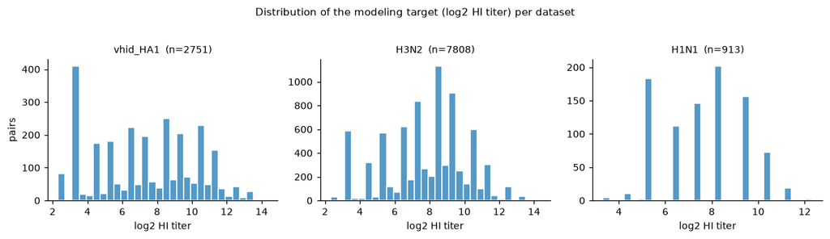

```python
fig, axes = plt.subplots(1, 3, figsize=(11, 3))
for ax, ds in zip(axes, A.DATASETS):
    ax.hist(data[ds]["y"], bins=30, color="#5499c7", edgecolor="white")
    ax.set_title(f"{ds}  (n={data[ds]['n']})", fontsize=9)
    ax.set_xlabel("log2 HI titer"); ax.set_ylabel("pairs" if ds == A.DATASETS[0] else "")
fig.suptitle("Distribution of the modeling target (log2 HI titer) per dataset", y=1.03, fontsize=10)
fig.tight_layout()
fig.savefig(os.path.join(A.FIG_DIR, "target_distribution.png"), dpi=130, bbox_inches="tight")
plt.show()
```

## 3. Results

We now walk through each analytical step and report what it produced. Because the Methods section covers only the data, each subsection below opens by stating *how* the step is done, then presents its output and interprets it — moving from *prediction* to *cause*: first how much of the HI signal is learnable and how nonlinear it is, which fixes what any mechanistic account must explain; then the positions that plausibly *drive* the signal and their dependency structure; then the interpretable predictor and the epistasis it exposes; and finally the convergent driver claims, their confounding-adjusted effect sizes, and the validation of the discovered graph. No number or figure is presented without interpreting how it supports the point.

### 3.1 Predictive benchmark

We first establish how much of the HI signal is learnable and whether it is multivariable and nonlinear. For each dataset we compare, on a held-out 20% test split, the best single position (max univariate R²), LASSO, Ridge, and XGBoost.

The benchmark below reports, for each dataset, the held-out test R² of the best single position, LASSO, Ridge, and XGBoost.

```python
bench = {ds: A.benchmark(data, ds) for ds in A.DATASETS}
bench_tbl = pd.DataFrame([dict(dataset=ds, **bench[ds]) for ds in A.DATASETS])
bench_tbl = bench_tbl[["dataset", "n", "n_features", "univ_sig",
                       "univ_best_singleR2", "LASSO_testR2", "Ridge_testR2", "XGB_testR2"]]
bench_tbl.round(3)
```

```
Out[4]:
    dataset     n  n_features  ...  LASSO_testR2  Ridge_testR2  XGB_testR2
0  vhid_HA1  2751         102  ...         0.751         0.754       0.862
1      H3N2  7808         312  ...         0.509         0.522       0.618
2      H1N1   913          70  ...         0.444         0.419       0.562

[3 rows x 8 columns]
```

|  | dataset | n | n_features | univ_sig | univ_best_singleR2 | LASSO_testR2 | Ridge_testR2 | XGB_testR2 |
| --- | --- | --- | --- | --- | --- | --- | --- | --- |
| 0 | vhid_HA1 | 2751 | 102 | 78 | 0.443 | 0.751 | 0.754 | 0.862 |
| 1 | H3N2 | 7808 | 312 | 185 | 0.205 | 0.509 | 0.522 | 0.618 |
| 2 | H1N1 | 913 | 70 | 56 | 0.167 | 0.444 | 0.419 | 0.562 |

In every dataset the ordering is XGBoost ≳ LASSO ≈ Ridge ≫ best single position. The large gap from best-single-position to the multivariable models shows the signal is **distributed across many positions**; the XGBoost margin over the linear models indicates **nonlinear / interaction structure** — the motivation for the KAN (Section 3.5). We add the KAN test R² to this comparison in Section 3.5.

### 3.2 Cross-validated R² with confidence intervals

A single split gives a point estimate but no uncertainty, so we repeat k-fold cross-validation to attach 95% confidence intervals to each method's R². LASSO, Ridge, and XGBoost use 5×4 repeated k-fold; the KAN uses 3-fold (GPU cost). The repeated k-fold fold scores are loaded from `results/cv_r2_folds.json` by default (recompute with `RECOMPUTE_CV=1`, ~40 min); the `cv_linear_tree` function below is the exact code that produced them, and the KAN folds are always loaded from `results/` (GPU-trained in the study).

The cross-validated intervals below test whether the single-split ordering holds under resampling.

```python
from scipy import stats
from sklearn.model_selection import RepeatedKFold
from sklearn.preprocessing import StandardScaler
from sklearn.linear_model import LassoCV, Ridge
from sklearn.metrics import r2_score
import xgboost as xgb

def cv_linear_tree(ds, n_splits=5, n_repeats=4, seed=A.SEED):
    d = data[ds]; cols = A.variant_columns(d["Xb"])
    X, y = d["Xg"][:, cols], d["y"]
    rkf = RepeatedKFold(n_splits=n_splits, n_repeats=n_repeats, random_state=seed)
    out = {"LASSO": [], "Ridge": [], "XGBoost": []}
    for tr, te in rkf.split(X):
        sc = StandardScaler().fit(X[tr]); Xtr, Xte = sc.transform(X[tr]), sc.transform(X[te])
        out["LASSO"].append(r2_score(y[te], LassoCV(alphas=np.logspace(-3,0,12), cv=3,
                             max_iter=20000).fit(Xtr, y[tr]).predict(Xte)))
        out["Ridge"].append(r2_score(y[te], Ridge(alpha=10.0).fit(Xtr, y[tr]).predict(Xte)))
        dtr, dte = xgb.DMatrix(X[tr], label=y[tr]), xgb.DMatrix(X[te], label=y[te])
        bst = xgb.train({"max_depth":4,"eta":0.1,"subsample":0.8,"colsample_bytree":0.8,
                         "objective":"reg:squarederror"}, dtr, num_boost_round=300,
                        evals=[(dte,"te")], early_stopping_rounds=20, verbose_eval=False)
        out["XGBoost"].append(r2_score(y[te], bst.predict(dte, iteration_range=(0, bst.best_iteration+1))))
    return out

# The 5x4 repeated k-fold CV is heavy (~40 min, mostly 20 XGBoost fits on the
# 7808x312 H3N2 matrix). Load the study fold scores by default; RECOMPUTE_CV=1 reruns.
saved_folds = A.load_result("cv_r2_folds.json")
if A.RECOMPUTE_CV:
    cv_folds = {ds: cv_linear_tree(ds) for ds in A.DATASETS}
else:
    cv_folds = {ds: {m: saved_folds[ds][m] for m in ["LASSO", "Ridge", "XGBoost"]}
                for ds in A.DATASETS}
# KAN CV folds always loaded from the study (GPU-trained)
for ds in A.DATASETS:
    cv_folds[ds]["KAN"] = saved_folds[ds]["KAN"]
print("CV folds:", "recomputed" if A.RECOMPUTE_CV else "loaded from results/cv_r2_folds.json")

def ci95(v):
    v = np.array(v, float); m = v.mean()
    if len(v) < 2: return m, m, m
    se = v.std(ddof=1)/np.sqrt(len(v)); lo, hi = stats.t.interval(0.95, len(v)-1, loc=m, scale=se)
    return m, lo, hi

cv_rows = []
for ds in A.DATASETS:
    for meth in ["LASSO","Ridge","XGBoost","KAN"]:
        m, lo, hi = ci95(cv_folds[ds][meth])
        cv_rows.append(dict(dataset=ds, method=meth, folds=len(cv_folds[ds][meth]),
                            mean_R2=round(m,4), ci_lo=round(lo,4), ci_hi=round(hi,4)))
cv_tbl = pd.DataFrame(cv_rows)
cv_tbl
```

```
CV folds: recomputed
Out[5]:
     dataset   method  folds  mean_R2   ci_lo   ci_hi
0   vhid_HA1    LASSO     20   0.7386  0.7338  0.7434
1   vhid_HA1    Ridge     20   0.7426  0.7371  0.7482
2   vhid_HA1  XGBoost     20   0.8528  0.8481  0.8575
3   vhid_HA1      KAN      3   0.8230  0.7758  0.8701
4       H3N2    LASSO     20   0.5023  0.4953  0.5093
5       H3N2    Ridge     20   0.5185  0.5121  0.5250
6       H3N2  XGBoost     20   0.6232  0.6158  0.6306
7       H3N2      KAN      3   0.5789  0.5318  0.6259
8       H1N1    LASSO     20   0.5316  0.5080  0.5552
9       H1N1    Ridge     20   0.5307  0.5059  0.5555
10      H1N1  XGBoost     20   0.6208  0.6056  0.6361
11      H1N1      KAN      3   0.5918  0.5077  0.6759
```

|  | dataset | method | folds | mean_R2 | ci_lo | ci_hi |
| --- | --- | --- | --- | --- | --- | --- |
| 0 | vhid_HA1 | LASSO | 20 | 0.7386 | 0.7338 | 0.7434 |
| 1 | vhid_HA1 | Ridge | 20 | 0.7426 | 0.7371 | 0.7482 |
| 2 | vhid_HA1 | XGBoost | 20 | 0.8528 | 0.8481 | 0.8575 |
| 3 | vhid_HA1 | KAN | 3 | 0.8230 | 0.7758 | 0.8701 |
| 4 | H3N2 | LASSO | 20 | 0.5023 | 0.4953 | 0.5093 |
| 5 | H3N2 | Ridge | 20 | 0.5185 | 0.5121 | 0.5250 |
| 6 | H3N2 | XGBoost | 20 | 0.6232 | 0.6158 | 0.6306 |
| 7 | H3N2 | KAN | 3 | 0.5789 | 0.5318 | 0.6259 |
| 8 | H1N1 | LASSO | 20 | 0.5316 | 0.5080 | 0.5552 |
| 9 | H1N1 | Ridge | 20 | 0.5307 | 0.5059 | 0.5555 |
| 10 | H1N1 | XGBoost | 20 | 0.6208 | 0.6056 | 0.6361 |
| 11 | H1N1 | KAN | 3 | 0.5918 | 0.5077 | 0.6759 |

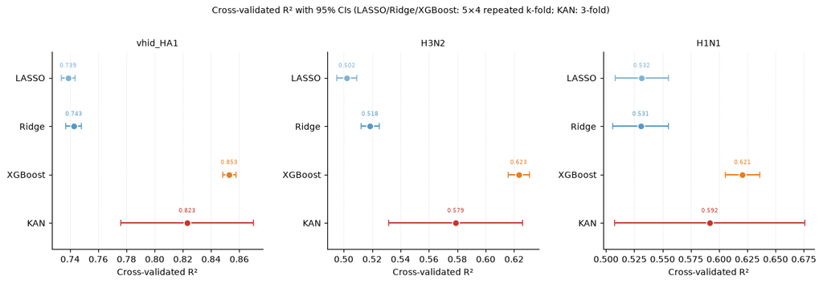

```python
fig, axes = plt.subplots(1, 3, figsize=(12, 4))
order = ["LASSO","Ridge","XGBoost","KAN"]
for ax, ds in zip(axes, A.DATASETS):
    sub = cv_tbl[cv_tbl.dataset == ds]; yv = np.arange(len(order))[::-1]
    for yi, meth in zip(yv, order):
        r = sub[sub.method == meth].iloc[0]
        ax.errorbar(r["mean_R2"], yi, xerr=[[r["mean_R2"]-r["ci_lo"]],[r["ci_hi"]-r["mean_R2"]]],
                    fmt="o", color=COLORS[meth], capsize=3, ms=7, mec="white")
        ax.text(r["mean_R2"], yi+0.22, f"{r['mean_R2']:.3f}", ha="center", fontsize=6, color=COLORS[meth])
    ax.set_yticks(yv); ax.set_yticklabels(order); ax.set_title(ds, fontsize=9)
    ax.set_xlabel("Cross-validated R²"); ax.grid(axis="x", ls=":", lw=0.5, alpha=0.6); ax.margins(y=0.18)
fig.suptitle("Cross-validated R² with 95% CIs (LASSO/Ridge/XGBoost: 5×4 repeated k-fold; KAN: 3-fold)", y=1.02, fontsize=9)
fig.tight_layout()
fig.savefig(os.path.join(A.FIG_DIR, "cv_r2.png"), dpi=130, bbox_inches="tight"); plt.show()
```

XGBoost has the highest cross-validated R² in VHID and H3N2; on H1N1 the KAN's interval overlaps XGBoost's. The intervals are tight for the two larger datasets and wider for H1N1 (n=913), as expected. These CIs confirm the single-split benchmark ordering is not an artifact of one partition.

### 3.3 Causal discovery

We treat HI titer as a causal **sink**: HA sequence differences cause the titer, not vice-versa. Encoding this as background knowledge orients every feature→target edge into the target, so the target's *parents* are its direct-cause candidates.

The pipeline is: **power filter** (drop invariant / rare positions) → **linkage collapse** (merge positions with |φ|≥0.8 into one representative locus per co-evolving block) → **PC** (constraint-based) and **GES** (score-based) discovery → **200× bootstrap** for selection-stability tiers. Linkage collapse is the load-bearing step: near-deterministic co-evolution violates faithfulness and makes search intractable, and collapsing restores both. Every causal claim then attaches to a *block*, so we always report block size. FCI (latent-aware) is run only for VHID, because causal-learn's FCI *possible-d-sep* step does not terminate in practical time on the denser H3N2/H1N1 collapsed graphs (>30 min at ≥24 nodes); for those we report PC + GES + bootstrap, and very wide graphs are screened to the top loci by target association first.

Running this pipeline yields, per dataset, the collapsed loci, the PC/GES parent sets, and the bootstrap-stability tiers below.

```python
import causal_helpers as ch

collapsed = {}
for ds in A.DATASETS:
    Adf, blocks = A.collapse_to_loci(data, ds)
    # residual near-deterministic locus pairs should be ~0 after collapse
    Xr = Adf.drop(columns="HI_titer").values
    resid = int((np.abs(np.corrcoef(Xr.T))[np.triu_indices(Xr.shape[1], 1)] >= 0.9).sum())
    collapsed[ds] = dict(A=Adf, blocks=blocks, n_loci=Adf.shape[1]-1,
                         n_multiblocks=sum(1 for v in blocks.values() if len(v) > 1),
                         residual_strong_pairs=resid)

collapse_tbl = pd.DataFrame([
    dict(dataset=ds, variant_positions=len(A.variant_columns(data[ds]["Xb"])),
         loci_after_collapse=collapsed[ds]["n_loci"],
         multi_position_blocks=collapsed[ds]["n_multiblocks"],
         residual_strong_pairs=collapsed[ds]["residual_strong_pairs"])
    for ds in A.DATASETS])
collapse_tbl
```

```
Out[7]:
    dataset  variant_positions  ...  multi_position_blocks  residual_strong_pairs
0  vhid_HA1                102  ...                     10                      0
1      H3N2                312  ...                      9                      0
2      H1N1                 70  ...                     11                      0

[3 rows x 5 columns]
```

|  | dataset | variant_positions | loci_after_collapse | multi_position_blocks | residual_strong_pairs |
| --- | --- | --- | --- | --- | --- |
| 0 | vhid_HA1 | 102 | 71 | 10 | 0 |
| 1 | H3N2 | 312 | 123 | 9 | 0 |
| 2 | H1N1 | 70 | 34 | 11 | 0 |

Residual strong locus pairs (|φ|≥0.9) drop to **0** in all three datasets, confirming that linkage collapse succeeded and restored the conditions discovery needs. PC and GES then run on the collapsed loci, and the bootstrap tiers below rank each candidate.

```python
# PC + GES live (fast). FCI only for vhid. Bootstrap tiers: reuse results/ by default.
causal_saved = A.load_result("causal_results.json")

def run_pc_ges(ds, screen_over=75, screen_k=60):
    Adf = collapsed[ds]["A"]; n_loci = Adf.shape[1]-1
    sk = lambda s: int(s[3:])
    if n_loci > screen_over:
        feats = ch.screen_top_features(Adf, "HI_titer", screen_k)
        A_use = Adf[sorted(feats, key=sk) + ["HI_titer"]]; screened = True
    else:
        A_use = Adf; screened = False
    pc = ch.discover_target_parents(A_use, "HI_titer", method="pc", alpha=0.01)
    ges = ch.ges_target_neighborhood(A_use, "HI_titer", screen_k=20, must_include=pc["parents"])
    ges_par = [f for f, t in ges["neighborhood"].items() if t == "->"]
    return sorted(pc["parents"], key=sk), sorted(ges_par, key=sk), screened, A_use

pc_ges = {}
for ds in A.DATASETS:
    pc_par, ges_par, screened, _ = run_pc_ges(ds)
    pc_ges[ds] = dict(pc=pc_par, ges=ges_par, screened=screened)
    print(f"{ds}: PC={pc_par}")
    print(f"{'':>{len(ds)}}  GES={ges_par}  (screened={screened})")
```

```
vhid_HA1: PC=['pos144', 'pos156', 'pos158', 'pos189', 'pos289']
          GES=['pos50', 'pos133', 'pos144', 'pos145', 'pos262', 'pos276']  (screened=False)
H3N2: PC=['pos11', 'pos88', 'pos143', 'pos167', 'pos168', 'pos199', 'pos200', 'pos203', 'pos288']
      GES=['pos93', 'pos143', 'pos167', 'pos168', 'pos182', 'pos207', 'pos286']  (screened=True)
H1N1: PC=['pos53', 'pos135', 'pos151', 'pos199', 'pos232']
      GES=['pos4', 'pos53', 'pos131', 'pos135', 'pos151', 'pos163', 'pos167', 'pos199', 'pos232', 'pos283']  (screened=False)
```

```python
# Bootstrap stability tiers. Recompute (~30 min on H3N2) or reuse the study results.
if A.RECOMPUTE_CAUSAL:
    boot_freq = {}
    for ds in A.DATASETS:
        _, _, _, A_use = run_pc_ges(ds)
        bs = ch.bootstrap_target_parents(A_use, "HI_titer", B=A.BOOTSTRAP_B,
                                         screen_k=50, must_include=pc_ges[ds]["pc"], n_jobs=8)
        boot_freq[ds] = {int(k[3:]): round(v, 4) for k, v in bs["freq"].items()}
else:
    boot_freq = {ds: {int(k[3:]): v for k, v in causal_saved[ds]["bootstrap_freq"].items()}
                 for ds in A.DATASETS}

blocks_all = {ds: collapsed[ds]["blocks"] for ds in A.DATASETS}

def causal_table(ds):
    hi, md_ = A.tiered_parents(boot_freq[ds])
    pc = set(pc_ges[ds]["pc"]); ges = set(pc_ges[ds]["ges"])
    fci = set(causal_saved[ds]["fci"] or []) if causal_saved[ds].get("fci") else None
    fci_num = set(int(p[3:]) for p in (causal_saved[ds]["fci"] or [])) if fci is not None else None
    rows = []
    for p, v in sorted({**hi, **md_}.items(), key=lambda kv: -kv[1]):
        pn = f"pos{p}"
        rows.append(dict(position=p, bootstrap_freq=round(v,3),
            tier="high" if v >= A.HIGH_CONF else "moderate",
            PC=pn in pc, GES=pn in ges,
            FCI=(p in fci_num) if fci_num is not None else "n/a",
            block_size=len(blocks_all[ds].get(p, [p]))))
    return pd.DataFrame(rows)

causal_tables = {ds: causal_table(ds) for ds in A.DATASETS}
for ds in A.DATASETS:
    print(f"=== {ds} (FCI {'run' if causal_saved[ds].get('fci') else 'omitted — see text'}) ===")
    display(causal_tables[ds])
```

```
=== vhid_HA1 (FCI run) ===
=== H3N2 (FCI omitted — see text) ===
=== H1N1 (FCI omitted — see text) ===
```

|  | position | bootstrap_freq | tier | PC | GES | FCI | block_size |
| --- | --- | --- | --- | --- | --- | --- | --- |
| 0 | 156 | 1.000 | high | True | False | True | 1 |
| 1 | 189 | 1.000 | high | True | False | True | 1 |
| 2 | 289 | 0.955 | high | True | False | True | 1 |
| 3 | 158 | 0.950 | high | True | False | True | 1 |
| 4 | 144 | 0.505 | moderate | True | True | False | 1 |

|  | position | bootstrap_freq | tier | PC | GES | FCI | block_size |
| --- | --- | --- | --- | --- | --- | --- | --- |
| 0 | 11 | 1.000 | high | True | False | n/a | 9 |
| 1 | 143 | 1.000 | high | True | True | n/a | 1 |
| 2 | 167 | 1.000 | high | True | True | n/a | 1 |
| 3 | 168 | 1.000 | high | True | True | n/a | 1 |
| 4 | 199 | 1.000 | high | True | False | n/a | 1 |
| 5 | 203 | 0.995 | high | True | False | n/a | 1 |
| 6 | 288 | 0.815 | moderate | True | False | n/a | 1 |
| 7 | 200 | 0.650 | moderate | True | False | n/a | 1 |

|  | position | bootstrap_freq | tier | PC | GES | FCI | block_size |
| --- | --- | --- | --- | --- | --- | --- | --- |
| 0 | 151 | 1.000 | high | True | True | n/a | 1 |
| 1 | 135 | 0.825 | moderate | True | True | n/a | 1 |
| 2 | 53 | 0.795 | moderate | True | True | n/a | 5 |
| 3 | 199 | 0.520 | moderate | True | True | n/a | 1 |

The bootstrap frequency tiers each candidate into **high** (≥0.9), **moderate** (0.5–0.9), or unstable. High-confidence parents are: VHID {156, 189, 289, 158}; H3N2 {11, 143, 167, 168, 199, 203}; H1N1 {151}. Positions with `block_size > 1` (e.g. H3N2 pos11 = 9-position block, H1N1 pos53 = 5) carry claims for the whole block, not the single position. GES independently confirms the PC parents 143/167/168 in H3N2 and 151/135/53 in H1N1.

### 3.4 The discovered dependency structure

We visualize each dataset's learned structure as a **titer-sink graph**: every retained direct-cause candidate is a colored arrow into the HI-titer node, with width and opacity proportional to its bootstrap stability and color by tier. But is this a strict *star* — positions that each affect titer while being mutually independent? We test that directly rather than assume it, running a partial-correlation skeleton over each parent set plus titer, which asks two questions:

1. **Are any parents pure intermediates?** A position that reaches titer only through another (posₐ → pos_P → titer, no direct edge) would become conditionally independent of titer once the other parents are conditioned on, and drop out. We test each parent against titer given all *other* parents.
2. **Are the parents mutually independent?** We test every parent–parent pair for adjacency given all the *other parents* (excluding titer — since titer is a common child of the parents, conditioning on it would induce spurious dependence by the collider / explaining-away effect). Any surviving edge means the star is incomplete.

The grey arcs overlaid on the graph are the significant parent–parent adjacencies from test 2. They are drawn **without arrowheads**: a partial correlation cannot distinguish posₐ → pos_b from shared-ancestry confounding (posₐ ← L → pos_b), so their direction is not identified.

The titer-sink graphs below show each dataset's retained direct-cause candidates and the parent–parent adjacencies from the skeleton test.

```
vhid_HA1: 5/5 parents remain directly titer-adjacent given the others (no pure mediators); 5 of 10 parent-parent pairs are adjacent => NOT a star (parents interdependent)
H3N2: 8/8 parents remain directly titer-adjacent given the others (no pure mediators); 21 of 28 parent-parent pairs are adjacent => NOT a star (parents interdependent)
H1N1: 4/4 parents remain directly titer-adjacent given the others (no pure mediators); 4 of 6 parent-parent pairs are adjacent => NOT a star (parents interdependent)
```

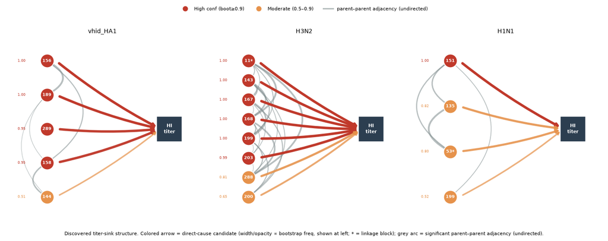

```python
skel = {ds: A.parent_skeleton(ds, data, causal_saved) for ds in A.DATASETS}
fig, axes = plt.subplots(1, 3, figsize=(13, 4.6))
for ax, ds in zip(axes, A.DATASETS):
    A.draw_titer_dag(ax, ds, boot_freq[ds], blocks_all[ds], among_edges=skel[ds]["among"])
from matplotlib.lines import Line2D
leg = [Line2D([0],[0],marker="o",color="w",mfc="#c0392b",ms=9,label="High conf (boot≥0.9)"),
       Line2D([0],[0],marker="o",color="w",mfc="#e6924b",ms=9,label="Moderate (0.5–0.9)"),
       Line2D([0],[0],color="#7f8c8d",lw=2,alpha=0.6,label="parent–parent adjacency (undirected)")]
fig.legend(handles=leg, ncol=3, fontsize=7.5, frameon=False, loc="upper center", bbox_to_anchor=(0.5,1.04))
fig.suptitle("Discovered titer-sink structure. Colored arrow = direct-cause candidate "
             "(width/opacity ∝ bootstrap freq, shown at left; * = linkage block); "
             "grey arc = significant parent–parent adjacency (undirected).",
             fontsize=7.3, y=-0.02)
fig.tight_layout()
fig.savefig(os.path.join(A.FIG_DIR, "dag.png"), dpi=130, bbox_inches="tight"); plt.show()

# report the two structural tests
for ds in A.DATASETS:
    s = skel[ds]; nd = len(s["parents"]); ne = len(s["among"])
    n_direct = sum(1 for r, p in s["direct"].values() if p < 0.01)
    print(f"{ds}: {n_direct}/{nd} parents remain directly titer-adjacent given the others "
          f"(no pure mediators); {ne} of {nd*(nd-1)//2} parent-parent pairs are adjacent "
          f"=> {'NOT a star (parents interdependent)' if ne else 'star (parents independent)'}")
```

#### 3.4.1 Expanding causal survivors to their 12 property axes

Causal discovery (§3.3–3.4) ran deliberately at **one scalar per position** — the Grantham distance — because feeding twelve correlated property axes per site into PC/FCI would stack *within-position* collinearity on top of the cross-position linkage the collapse step already handles, worsening the faithfulness violations the method is built to avoid. That keeps discovery tractable and faithful, but it leaves each surviving position described by a single lumped distance.

The **bridge** is the hybrid's second half. We take *only the positions that survived causal discovery* (bootstrap frequency ≥ 0.9, each collapsed locus expanded through its linkage block to member positions) and re-express each one in its full **12-dimensional property encoding** from the Amino Acid Transition Vector Toolkit (`src/aa_transition_vector_toolkit.py`, scales in `src/aa_properties.json`): Grantham composition/polarity/volume, Kyte–Doolittle hydropathy, charge, Chou–Fasman helix/sheet/turn propensity, aromaticity, flexibility, and side-chain H-bond donor/acceptor counts. Each feature is the change `property(virus) − property(reference)` at that site, named `pos{k}__{property}` (e.g. `pos156__charge`).

This is the right division of labour: **discovery stays low-dimensional and faithful**, while **interpretation becomes high-resolution** — the KAN in §3.5 can now attribute a survivor's effect to a *specific property at a specific site* ("charge reversal at position 156") rather than a single distance. Property axes that never vary at a given survivor site (e.g. aromaticity where no aromatic substitution occurs) carry no signal and are dropped.

```python
# Step A -> B bridge: expand each dataset's high-confidence causal survivors
# (bootstrap freq >= 0.9, linkage-block-expanded) to their 12 property axes.
# Build the position x property matrices once here; reused by 3.4.2, 3.5, 3.6.2.
prop_mats = A.load_property_matrices()
kan_bridge = {ds: A.build_kan_hybrid_input(ds, causal=causal_saved, prop=prop_mats[ds])
              for ds in A.DATASETS}

bridge_tbl = pd.DataFrame([{
    "dataset": ds,
    "causal survivors": len(kan_bridge[ds]["survivors"]),
    "survivor positions": ", ".join(map(str, kan_bridge[ds]["survivors"])),
    "property features (survivors x 12)": kan_bridge[ds]["X_scaled"].shape[1],
    "constant axes dropped": len(kan_bridge[ds]["dropped_constant"]),
} for ds in A.DATASETS])
display(bridge_tbl)
for ds in A.DATASETS:
    b = kan_bridge[ds]
    print(f"{ds}: {len(b['survivors'])} survivors x 12 -> {b['X_scaled'].shape[1]} property features "
          f"(dropped {len(b['dropped_constant'])} zero-variance axes)")
```

```
vhid_HA1: 4 survivors x 12 -> 44 property features (dropped 4 zero-variance axes)
H3N2: 14 survivors x 12 -> 142 property features (dropped 26 zero-variance axes)
H1N1: 1 survivors x 12 -> 11 property features (dropped 1 zero-variance axes)
```

|  | dataset | causal survivors | survivor positions | property features (survivors x 12) | constant axes dropped |
| --- | --- | --- | --- | --- | --- |
| 0 | vhid_HA1 | 4 | 156, 158, 189, 289 | 44 | 4 |
| 1 | H3N2 | 14 | 11, 64, 143, 153, 156, 167, 168, 173, 199, 203... | 142 | 26 |
| 2 | H1N1 | 1 | 151 | 11 | 1 |

#### 3.4.2 Causal discovery at property resolution (the 12D encoding)

The DAG in §3.4 discovers *which positions* are direct causes of titer, using a single scalar (Grantham distance) per position. A natural next question — and one raised in review — is **which physicochemical axis** at each causal position carries the effect. Here we repeat the same target-oriented causal discovery, but replace each survivor position's scalar Grantham distance with its **12-dimensional property-change vector** from the Step A→B bridge (§3.4.1). The PC parents of `HI_titer_log2` are then specific `pos{k}__{property}` axes, not whole positions.

One subtlety must be handled first. The 12 property axes at a *single* position are near-collinear — composition, polarity and volume are all deterministic functions of the same amino-acid substitution — so the survivors×12 matrix is badly rank-deficient and the Fisher-z conditional-independence test hits a singular correlation matrix. We therefore run a **rank-revealing (column-pivoted) QR** first to keep only a well-conditioned, numerically independent subset of property axes before discovery.

```
vhid_HA1: PC parents = ['pos189__sheet', 'pos289__turn']  |  bootstrap-stable axes = [('pos289__turn', 1.0), ('pos189__sheet', 0.91)]
H3N2: PC parents = ['pos153__flexibility', 'pos168__flexibility']  |  bootstrap-stable axes = [('pos168__flexibility', 1.0), ('pos153__flexibility', 0.88)]
H1N1: PC parents = []  |  bootstrap-stable axes = []
```

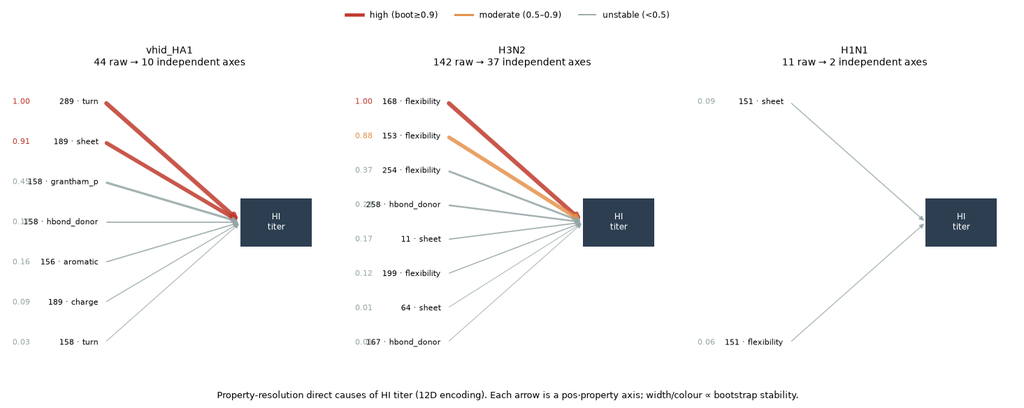

```python
# 12D-property causal discovery: PC + terminal background knowledge on the causal
# survivors' property axes (rank-revealing QR decorrelation first). Bootstrap the
# edge selection to tier each property axis by stability.
causal12d = {ds: A.causal_discovery_12d(ds, causal=causal_saved, prop=prop_mats[ds])
             for ds in A.DATASETS}
boot12d = {ds: A.bootstrap_causal_12d(ds, causal=causal_saved, prop=prop_mats[ds],
                                      B=A.BOOTSTRAP_B) for ds in A.DATASETS}

# Property-resolution DAG: survivor positions -> retained property axes -> HI titer,
# colouring each axis by its bootstrap stability.
import matplotlib.pyplot as plt
fig, axes = plt.subplots(1, 3, figsize=(13.5, 4.8))
for ax, ds in zip(axes, A.DATASETS):
    freq = boot12d[ds]["freq"]
    axesorted = sorted(freq.items(), key=lambda t: -t[1])[:8]
    ax.axis("off")
    ax.set_title(f"{ds}\n{causal12d[ds]['n_raw']} raw → {causal12d[ds]['n_vars']} independent axes",
                 fontsize=9)
    if not axesorted:
        ax.text(0.5, 0.5, "no property axis reaches\nsignificance (single-position\nrank limit)",
                ha="center", va="center", fontsize=8, transform=ax.transAxes); continue
    ax.add_patch(plt.Rectangle((0.72, 0.42), 0.22, 0.16, fc="#2c3e50", ec="none",
                 transform=ax.transAxes))
    ax.text(0.83, 0.5, "HI\ntiter", ha="center", va="center", color="w",
            fontsize=8, transform=ax.transAxes)
    n = len(axesorted)
    for i, (name, f) in enumerate(axesorted):
        yy = 0.9 - i * (0.8 / max(n - 1, 1))
        col = "#c0392b" if f >= A.HIGH_CONF else ("#e6924b" if f >= A.MOD_CONF else "#95a5a6")
        lw = 0.6 + 3.4 * f
        ax.annotate("", xy=(0.72, 0.5), xytext=(0.30, yy),
                    arrowprops=dict(arrowstyle="-|>", color=col, lw=lw, alpha=0.85),
                    xycoords="axes fraction", textcoords="axes fraction")
        ax.text(0.28, yy, name.replace("pos", "").replace("__", " · "),
                ha="right", va="center", fontsize=7.5, transform=ax.transAxes)
        ax.text(0.015, yy, f"{f:.2f}", ha="left", va="center", fontsize=7,
                color=col, transform=ax.transAxes)
from matplotlib.lines import Line2D
leg = [Line2D([0],[0],color="#c0392b",lw=3,label=f"high (boot≥{A.HIGH_CONF})"),
       Line2D([0],[0],color="#e6924b",lw=2,label=f"moderate ({A.MOD_CONF}–{A.HIGH_CONF})"),
       Line2D([0],[0],color="#95a5a6",lw=1.2,label="unstable (<0.5)")]
fig.legend(handles=leg, ncol=3, fontsize=8, frameon=False, loc="upper center",
           bbox_to_anchor=(0.5, 1.03))
fig.suptitle("Property-resolution direct causes of HI titer (12D encoding). "
             "Each arrow is a pos·property axis; width/colour ∝ bootstrap stability.",
             fontsize=8.5, y=-0.02)
fig.tight_layout()
fig.savefig(os.path.join(A.FIG_DIR, "dag_12d.png"), dpi=130, bbox_inches="tight"); plt.show()

for ds in A.DATASETS:
    stable = [(k, round(v, 2)) for k, v in sorted(boot12d[ds]["freq"].items(),
              key=lambda t: -t[1]) if v >= A.MOD_CONF]
    print(f"{ds}: PC parents = {causal12d[ds]['parents']}  |  bootstrap-stable axes = {stable}")
```

### 3.5 Interpretable prediction: a B-spline KAN

Kolmogorov–Arnold Networks (KANs) replace fixed node activations with *learnable univariate functions on each edge*. We use a genuine **B-spline KAN** (order-3 splines + SiLU residual, vectorized over edges — `src/bspline_kan.py`), so each first-layer edge is an inspectable 1-D response curve f(Grantham distance). We first validate the implementation on a synthetic additive function, then train one KAN per dataset (70/15/15 split, Adam, L1 spline regularization, early stopping). Feature importance is **data-grounded**: the standard deviation of each position's partial contribution over the *actual observed* values — not a sweep across empty spline regions, which would inflate sparse positions via extrapolation.

We train **two** KANs per dataset. The **hybrid** model (the guide's Step B primary) consumes the causal survivors' 12 property axes from the bridge above, giving per-(position × property) curves. A **baseline** model on all variant positions × single Grantham distance is retained both as the encoding comparison and as the *independent* position screen feeding the cross-method convergence in §3.7 — keeping it unrestricted avoids making that overlap circular. The synthetic-function validation and the per-dataset test R² are below.

```python
import torch
from sklearn.preprocessing import StandardScaler
sys.path.insert(0, "src")
from bspline_kan import BSplineKAN

DEVICE = "cuda" if torch.cuda.is_available() else "cpu"
print("KAN device:", DEVICE)

# --- validation on synthetic additive function 2*x0 + sin(3*x1) + 0.5*x2^2 ---
rng = np.random.RandomState(0)
Xs = rng.uniform(-3, 3, size=(2000, 5)); ys = 2*Xs[:,0] + np.sin(3*Xs[:,1]) + 0.5*Xs[:,2]**2 + 0.1*rng.randn(2000)
def _train(model, X, y, epochs=300, patience=40, lr=0.01, l1=1e-5, seed=0):
    torch.manual_seed(seed); rng = np.random.RandomState(seed)
    n=len(y); perm=rng.permutation(n); te=perm[:int(.15*n)]; va=perm[int(.15*n):int(.3*n)]; tr=perm[int(.3*n):]
    sc=StandardScaler().fit(X[tr]); Xt=torch.tensor(sc.transform(X),dtype=torch.float32,device=DEVICE)
    ym,ysd=y[tr].mean(),y[tr].std(); yt=torch.tensor((y-ym)/ysd,dtype=torch.float32,device=DEVICE).view(-1,1)
    model=model.to(DEVICE); opt=torch.optim.Adam(model.parameters(),lr=lr); best=(-1e9,None); bad=0
    from sklearn.metrics import r2_score
    for ep in range(epochs):
        model.train(); opt.zero_grad(); loss=((model(Xt[tr])-yt[tr])**2).mean()+model.regularization(l1)
        loss.backward(); opt.step(); model.eval()
        with torch.no_grad(): pv=model(Xt[va]).cpu().numpy().ravel()*ysd+ym
        r=r2_score(y[va],pv)
        if r>best[0]: best=(r,{k:v.detach().clone() for k,v in model.state_dict().items()}); bad=0
        else: bad+=1
        if bad>=patience: break
    model.load_state_dict(best[1]); model.eval()
    with torch.no_grad(): pte=model(Xt[te]).cpu().numpy().ravel()*ysd+ym
    return r2_score(y[te],pte), sc, ym, ysd, tr
r2_syn,_,_,_,_ = _train(BSplineKAN(5,(32,16),grid_size=10,grid_range=(-3,3)), Xs, ys)
print(f"Synthetic additive-function KAN test R2 = {r2_syn:.4f}  (expect ~0.99)")
```

```
KAN device: cuda
Synthetic additive-function KAN test R2 = 0.9987  (expect ~0.99)
```

```python
# --- Step B: two KANs per dataset ---------------------------------------
# (1) HYBRID (primary): causal survivors x 12 property axes  -> per-(position x
#     property) curves, so an effect is attributable to a specific property.
# (2) BASELINE: all variant positions x single Grantham distance -> the
#     position-level screen that feeds cross-method convergence (kept as an
#     INDEPENDENT position nominator so the four-method overlap in 3.7 is honest;
#     restricting it to survivors would make that overlap circular).
KAN_CFG = {"vhid_HA1": dict(hidden=(64,32), grid=10, lr=0.01, l1=1e-4, epochs=300, patience=40),
           "H3N2":     dict(hidden=(128,64), grid=12, lr=0.008, l1=5e-5, epochs=300, patience=60),
           "H1N1":     dict(hidden=(64,32), grid=10, lr=0.01, l1=1e-4, epochs=250, patience=40)}
from sklearn.metrics import r2_score

def _kan_importance(model, Xstd_tr, n_feat):
    """Data-grounded importance: SD of each feature's partial contribution over
    the observed (standardized) training values."""
    model.eval(); base = torch.zeros(1, n_feat, device=DEVICE)
    with torch.no_grad():
        f0 = model(base).item(); imp = np.zeros(n_feat)
        Xt = torch.tensor(Xstd_tr, dtype=torch.float32, device=DEVICE)
        for j in range(n_feat):
            xj = base.repeat(Xt.shape[0], 1); xj[:, j] = Xt[:, j]
            imp[j] = (model(xj).cpu().numpy().ravel() - f0).std()
    return imp

kan_out = {}          # baseline (position-level) -> feeds convergence in 3.7
kan_hybrid_out = {}   # hybrid (position x property) -> the mechanistic deliverable
for ds in A.DATASETS:
    cfg = KAN_CFG[ds]
    d = data[ds]

    # (1) HYBRID KAN on survivors x 12 property axes
    hb = kan_bridge[ds]; Xh, yh = hb["X_scaled"], hb["y"]; hnames = hb["feature_names"]
    mh = BSplineKAN(Xh.shape[1], cfg["hidden"], grid_size=cfg["grid"], grid_range=(-3,3))
    # Xh is already standardized; _train re-standardizes harmlessly (idempotent on z-scores)
    r2h, sch, ymh, ysdh, trh = _train(mh, Xh, yh, epochs=cfg["epochs"], patience=cfg["patience"],
                                       lr=cfg["lr"], l1=cfg["l1"], seed=A.SEED)
    imph = _kan_importance(mh, sch.transform(Xh)[trh], Xh.shape[1])
    order = np.argsort(-imph)
    top_props = [(hnames[i], float(imph[i])) for i in order[:12]]
    kan_hybrid_out[ds] = dict(r2_test=float(r2h), feature_names=hnames,
                              importance=dict(zip(hnames, imph.tolist())),
                              top_property_features=top_props,
                              survivors=hb["survivors"],
                              _model=mh, _scaler=sch, _ymean=ymh, _ystd=ysdh)

    # (2) BASELINE KAN on all variant positions x single Grantham distance
    cols = A.variant_columns(d["Xb"]); Xb_, yb_ = d["Xg"][:, cols], d["y"]
    mb = BSplineKAN(Xb_.shape[1], cfg["hidden"], grid_size=cfg["grid"], grid_range=(-3,3))
    r2b, scb, ymb, ysdb, trb = _train(mb, Xb_, yb_, epochs=cfg["epochs"], patience=cfg["patience"],
                                      lr=cfg["lr"], l1=cfg["l1"], seed=A.SEED)
    impb = _kan_importance(mb, scb.transform(Xb_)[trb], Xb_.shape[1])
    posnums = [A.pos_number(d["pos_cols"], c) for c in cols]
    top = [posnums[i] for i in np.argsort(-impb)[:15]]
    kan_out[ds] = dict(r2_test=float(r2b), top15=top, imp=dict(zip(posnums, impb.tolist())))

    print(f"{ds}: hybrid KAN (survivors x12) test R2 = {r2h:.3f} on {Xh.shape[1]} property feats "
          f"| baseline KAN (all pos) test R2 = {r2b:.3f}")
    print(f"    top property drivers: " +
          ", ".join(f"{n}({v:.2f})" for n,v in top_props[:5]))
```

```
vhid_HA1: hybrid KAN (survivors x12) test R2 = 0.667 on 44 property feats | baseline KAN (all pos) test R2 = 0.838
    top property drivers: pos189__hbond_acceptor(0.07), pos189__sheet(0.07), pos158__charge(0.06), pos189__helix(0.06), pos189__grantham_c(0.04)
H3N2: hybrid KAN (survivors x12) test R2 = 0.531 on 142 property feats | baseline KAN (all pos) test R2 = 0.614
    top property drivers: pos199__hydropathy(0.07), pos254__hydropathy(0.07), pos199__grantham_p(0.05), pos168__hbond_donor(0.05), pos168__turn(0.05)
H1N1: hybrid KAN (survivors x12) test R2 = 0.041 on 11 property feats | baseline KAN (all pos) test R2 = 0.594
    top property drivers: pos151__hbond_donor(0.01), pos151__hydropathy(0.01), pos151__grantham_v(0.01), pos151__hbond_acceptor(0.01), pos151__sheet(0.01)
```

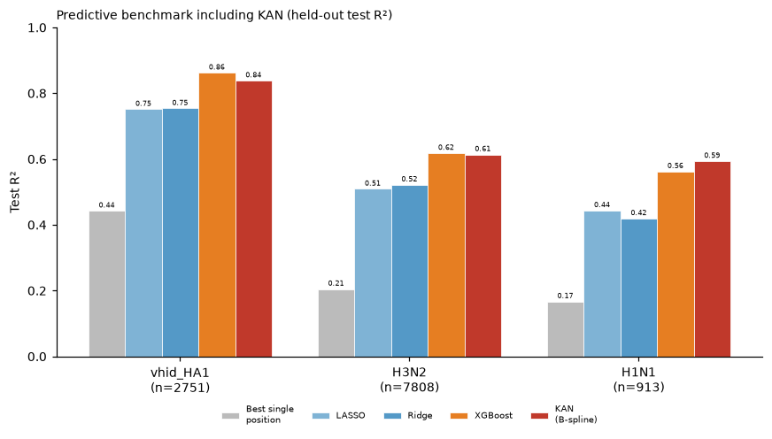

```python
# Benchmark + KAN R2 comparison figure
methods = ["univ_best_singleR2","LASSO_testR2","Ridge_testR2","XGB_testR2","KAN"]
labels = ["Best single\nposition","LASSO","Ridge","XGBoost","KAN\n(B-spline)"]
cols_bar = ["#bbbbbb","#7fb3d5","#5499c7","#e67e22","#c0392b"]
fig, ax = plt.subplots(figsize=(8, 4.6)); x = np.arange(len(A.DATASETS)); w = 0.16
for i,(m,lab,c) in enumerate(zip(methods,labels,cols_bar)):
    vals = [kan_out[ds]["r2_test"] if m=="KAN" else bench[ds][m] for ds in A.DATASETS]
    ax.bar(x+(i-2)*w, vals, w, label=lab, color=c, edgecolor="white", lw=0.5)
    for xi,v in zip(x+(i-2)*w, vals): ax.text(xi, v+0.01, f"{v:.2f}", ha="center", fontsize=5.4)
ax.set_xticks(x); ax.set_xticklabels([f"{ds}\n(n={data[ds]['n']})" for ds in A.DATASETS])
ax.set_ylabel("Test R²"); ax.set_ylim(0,1.0)
ax.legend(ncol=5, fontsize=6.5, frameon=False, loc="upper center", bbox_to_anchor=(0.5,-0.12))
ax.set_title("Predictive benchmark including KAN (held-out test R²)", fontsize=9, loc="left")
fig.tight_layout(); fig.savefig(os.path.join(A.FIG_DIR,"benchmark.png"), dpi=130, bbox_inches="tight"); plt.show()
```

The hybrid KAN's curves are the mechanistic payoff of the bridge. Where the baseline KAN learns one response per *position*, the hybrid learns one per *(position × property)*, so a non-flat curve names the physicochemical axis through which a confirmed causal site acts — for example whether escape at a survivor position tracks a **charge** change, a **volume** change, or a **hydrophobicity** change. Because the input is restricted to causal survivors, every curve shown sits at a position that already passed the structural (causal-discovery) filter; a non-flat curve here is the *functional* half of the two-part evidence the guide requires before attributing escape to a specific property at a specific site.

```
saved results/kan_hybrid_results.json
```

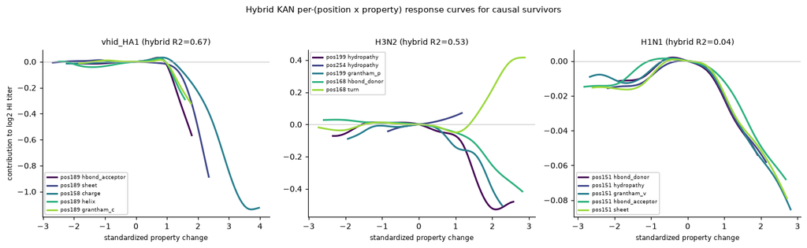

```python
# Hybrid KAN property-response curves: for the top property features, sweep the
# (standardized) property change across its observed range with others held at
# baseline, and read the network's partial contribution to log2 HI titer. This
# is the mechanistic payoff of the bridge -- a curve per (position x property).
fig, axes = plt.subplots(1, 3, figsize=(13, 3.8))
for ax, ds in zip(axes, A.DATASETS):
    hb = kan_bridge[ds]; Xh = hb["X_scaled"]; hnames = hb["feature_names"]
    oh = kan_hybrid_out[ds]
    mh, sch, ysdh = oh["_model"], oh["_scaler"], oh["_ystd"]
    Xstd = sch.transform(Xh)
    imp = np.array([oh["importance"][n] for n in hnames])
    top_idx = np.argsort(-imp)[:5]
    mh.eval(); base = torch.zeros(1, Xh.shape[1], device=DEVICE)
    with torch.no_grad(): f0 = mh(base).item()
    cmap = plt.cm.viridis(np.linspace(0, 0.85, len(top_idx)))
    for col, j in zip(cmap, top_idx):
        lo, hi = np.percentile(Xstd[:, j], [2, 98])
        xs = np.linspace(lo, hi, 80)
        xj = base.repeat(len(xs), 1).clone(); xj[:, j] = torch.tensor(xs, dtype=torch.float32, device=DEVICE)
        with torch.no_grad(): yj = (mh(xj).cpu().numpy().ravel() - f0) * ysdh
        ax.plot(xs, yj, color=col, lw=2, label=hnames[j].replace("__", " "))
    ax.axhline(0, color="#bbb", lw=0.6); ax.set_title(f"{ds} (hybrid R2={oh['r2_test']:.2f})", fontsize=9)
    ax.set_xlabel("standardized property change", fontsize=8)
    ax.set_ylabel("contribution to log2 HI titer" if ds==A.DATASETS[0] else "", fontsize=8)
    ax.legend(fontsize=5.6, loc="best", framealpha=0.9)
fig.suptitle("Hybrid KAN per-(position x property) response curves for causal survivors", fontsize=10, y=1.03)
fig.tight_layout(); fig.savefig(os.path.join(A.FIG_DIR, "hybrid_property_curves.png"), dpi=130, bbox_inches="tight")
plt.show()

# persist hybrid results (drop non-serializable model handles)
import json as _json
_ser = {ds: {k: v for k, v in kan_hybrid_out[ds].items() if not k.startswith("_")}
        for ds in A.DATASETS}
with open(os.path.join(A.RESULTS_DIR, "kan_hybrid_results.json"), "w") as _f:
    _json.dump(_ser, _f, indent=2)
print("saved results/kan_hybrid_results.json")
```

### 3.6 Capturing epistasis: a second-order KAN

The first-order KAN is **additive** — a sum of univariate curves — and a diagnostic (fitting depth-1 vs depth-6 gradient-boosted trees) shows that the entire accuracy gap between additive models and full XGBoost on these datasets is **epistasis**: position×position interactions. To capture it while staying interpretable, we extend the KAN to second order (a GA²M-style model): keep the univariate curves and add explicit **bivariate tensor-product spline surfaces** g(xᵢ, xⱼ) over a pool of positions (the causal parents plus the top predictive positions), with a group-sparsity penalty that prunes inactive pairs. Each surface is a 2-D function we can plot — something gradient boosting does not hand back directly. CV is **nested**: the interaction pool is re-selected on each training fold only, so the reported R² carries no feature-selection leakage. The pool size needed per dataset tracks how localized the epistasis is within the causal parents (measured separately): H1N1's interactions sit almost entirely on its parents (small pool), while VHID and H3N2 spread across more positions (wider pool).

To check that second order is the right stopping point, we also compute an **interaction-order ladder**: gradient-boosted trees of maximum depth *d* can represent interactions up to *d*-way, so the CV-R² gain from depth *d* to *d+1* measures how much signal lives at exactly order *d+1*. If the curve flattens after depth 2, pairwise terms capture essentially all the available interaction structure and third-and-higher-order terms would add little.

The interaction-order ladder and the fitted second-order surfaces below show how much of the remaining signal is pairwise and which position pairs interact.

```python
# Second-order KAN, nested 5-fold CV (interaction pool re-selected per training fold).
# GPU; ~1-2 min total. Compares against the first-order KAN and XGBoost CV from §4.2.
sokan_folds = {ds: A.sokan_cv(ds, data, causal_saved) for ds in A.DATASETS}
so_tbl = pd.DataFrame([{
    "dataset": ds,
    "KAN 1st-order": round(float(np.mean(cv_folds[ds]["KAN"])), 3),
    "KAN 2nd-order": round(float(np.mean(sokan_folds[ds])), 3),
    "KAN 2nd (±SD)": f"±{np.std(sokan_folds[ds]):.3f}",
    "XGBoost": round(float(np.mean(cv_folds[ds]["XGBoost"])), 3),
} for ds in A.DATASETS])
display(so_tbl)
print("Second-order KAN reaches XGBoost on VHID and H1N1 and comes within ~1 SD on H3N2,")
print("recovering the epistatic signal the additive KAN structurally cannot represent.")
```

```
Second-order KAN reaches XGBoost on VHID and H1N1 and comes within ~1 SD on H3N2,
recovering the epistatic signal the additive KAN structurally cannot represent.
```

|  | dataset | KAN 1st-order | KAN 2nd-order | KAN 2nd (±SD) | XGBoost |
| --- | --- | --- | --- | --- | --- |
| 0 | vhid_HA1 | 0.823 | 0.851 | ±0.010 | 0.853 |
| 1 | H3N2 | 0.579 | 0.613 | ±0.018 | 0.623 |
| 2 | H1N1 | 0.592 | 0.624 | ±0.039 | 0.621 |

```python
from sklearn.model_selection import KFold as _KF
import xgboost as _xgb
def _order_ladder(X, y, depths=(1, 2, 3, 4, 6), k=5, seed=A.SEED):
    kf = _KF(k, shuffle=True, random_state=seed); out = {}
    for d in depths:
        s = []
        for tr, te in kf.split(X):
            m = _xgb.XGBRegressor(n_estimators=400, max_depth=d, learning_rate=0.05,
                                  subsample=0.8, colsample_bytree=0.8, n_jobs=8,
                                  tree_method="hist", verbosity=0).fit(X[tr], y[tr])
            s.append(r2_score(y[te], m.predict(X[te])))
        out[d] = float(np.mean(s))
    return out
ladder = {}
for ds in A.DATASETS:
    d = data[ds]; var = A.variant_columns(d["Xb"])
    ladder[ds] = _order_ladder(d["Xg"][:, var], d["y"])
lad_tbl = pd.DataFrame({ds: {f"≤{d}-way (depth {d})": round(r, 3) for d, r in ladder[ds].items()}
                        for ds in A.DATASETS}).T
display(lad_tbl)
for ds in A.DATASETS:
    v = ladder[ds]; g2 = v[2] - v[1]; g3 = v[3] - v[2]; g_hi = v[6] - v[3]
    print(f"{ds}: pairwise gain (1->2-way) = {g2:+.3f}; 3-way gain (2->3) = {g3:+.3f}; "
          f"all higher (3->6-way) = {g_hi:+.3f}")
```

```
vhid_HA1: pairwise gain (1->2-way) = +0.073; 3-way gain (2->3) = +0.030; all higher (3->6-way) = +0.020
H3N2: pairwise gain (1->2-way) = +0.080; 3-way gain (2->3) = +0.037; all higher (3->6-way) = +0.042
H1N1: pairwise gain (1->2-way) = +0.067; 3-way gain (2->3) = +0.002; all higher (3->6-way) = -0.018
```

|  | ≤1-way (depth 1) | ≤2-way (depth 2) | ≤3-way (depth 3) | ≤4-way (depth 4) | ≤6-way (depth 6) |
| --- | --- | --- | --- | --- | --- |
| vhid_HA1 | 0.735 | 0.808 | 0.838 | 0.853 | 0.858 |
| H3N2 | 0.473 | 0.553 | 0.590 | 0.616 | 0.632 |
| H1N1 | 0.546 | 0.613 | 0.615 | 0.606 | 0.596 |

The second-order interaction terms close most of that gap, and unlike the trees the model exposes *which* pairs interact and *how*. We fit on the full data and render the strongest surfaces (ranked by norm). Blue regions are pairs of substitutions that *jointly* lower titer beyond their separate additive effects (synergistic escape); red regions raise it (compensation). Some top pairs are **parent×parent** (both partners already have stable direct effects — the cleanest epistasis claims), others involve a predictive-only partner, consistent with much of the interaction signal living outside the high-confidence causal-parent set.

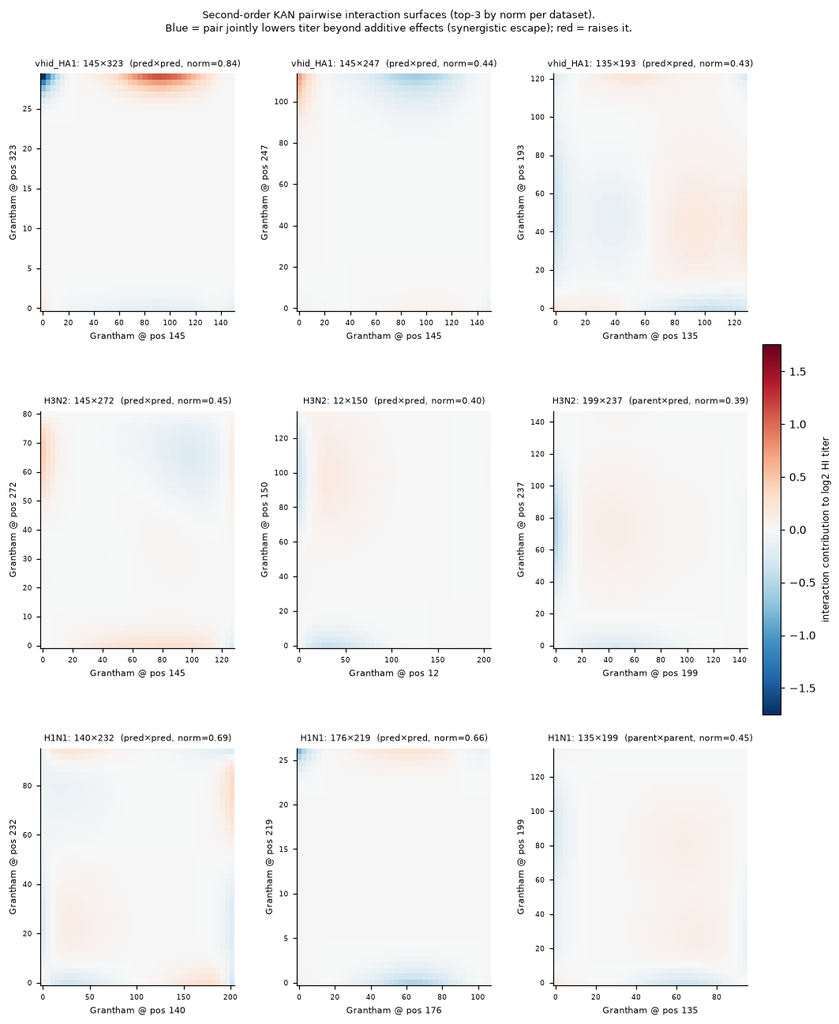

```python
import second_order_kan as SO
fig, axes = plt.subplots(3, 3, figsize=(11, 12.5))
# extra vertical room so each row's x-label ('Grantham @ pos X') clears the
# subplot title of the row beneath it
fig.subplots_adjust(hspace=0.42, wspace=0.32, top=0.9, bottom=0.06)
surf_cache = {}
allZ = []
for ds in A.DATASETS:
    m, sc, mu, sd, pool, pvi, pool_pos, parents = A.sokan_fit_full(ds, data, causal_saved)
    tops = SO.top_interactions(m, pool_pos, k=3)
    slot = {(pool_pos[m._ia[q]], pool_pos[m._ib[q]]): q for q in range(len(m.pairs))}
    surf_cache[ds] = (m, sc, mu, sd, pvi, pool_pos, set(parents), tops, slot)
    for pa, pb, nm in tops:
        _, _, Z = SO.interaction_surface(m, sc, mu, sd, slot[(pa, pb)], grid=40)
        allZ.append(np.abs(Z).max())
vmax = max(allZ)
for r, ds in enumerate(A.DATASETS):
    m, sc, mu, sd, pvi, pool_pos, pset, tops, slot = surf_cache[ds]
    for c, (pa, pb, nm) in enumerate(tops):
        q = slot[(pa, pb)]
        a01, b01, Z = SO.interaction_surface(m, sc, mu, sd, q, grid=40)
        ga = a01 * sc.rng[pvi[m._ia[q]]] + sc.lo[pvi[m._ia[q]]]
        gb = b01 * sc.rng[pvi[m._ib[q]]] + sc.lo[pvi[m._ib[q]]]
        ax = axes[r, c]
        im = ax.pcolormesh(ga, gb, Z.T, cmap="RdBu_r", vmin=-vmax, vmax=vmax, shading="auto")
        kind = f"{'parent' if pa in pset else 'pred'}×{'parent' if pb in pset else 'pred'}"
        ax.set_xlabel(f"Grantham @ pos {pa}", fontsize=7)
        ax.set_ylabel(f"Grantham @ pos {pb}", fontsize=7)
        ax.set_title(f"{ds}: {pa}×{pb}  ({kind}, norm={nm:.2f})", fontsize=7.5)
        ax.tick_params(labelsize=6)
cbar = fig.colorbar(im, ax=axes, fraction=0.025, pad=0.02)
cbar.set_label("interaction contribution to log2 HI titer", fontsize=8)
fig.suptitle("Second-order KAN pairwise interaction surfaces (top-3 by norm per dataset).\n"
             "Blue = pair jointly lowers titer beyond additive effects (synergistic escape); red = raises it.",
             fontsize=8.5, y=0.96)
fig.savefig(os.path.join(A.FIG_DIR, "interaction_surfaces.png"), dpi=140); plt.show()
```

#### 3.6.1 How high does the interaction order need to go? A first→second→third-order ladder

The second-order KAN closes most of the additive KAN's gap to gradient-boosted trees, but on H3N2 a small gap remains, and a reasonable objection is that the model may simply be stopping one order too early — that genuine **three-way** epistasis (residues acting only as a trio) is being missed. We test this directly by extending the model to an explicit **third-order KAN** (`src/third_order_kan.py`): on top of the univariate curves and bivariate surfaces it adds trivariate tensor-product spline *volumes* $g_{ijk}(x_i,x_j,x_k)$ over a small pool of the most interaction-active position triples.

We then read a like-for-like nested-CV ladder — additive (1st) → pairwise (2nd) → three-way (3rd) KAN — against XGBoost on the same folds. If the residual gap is higher-order epistasis, the third-order rung should rise toward XGBoost; if the signal is genuinely pairwise-dominant, the third rung should sit flat on the second.

```
dataset        1st     2nd     3rd     XGB   2nd->3rd gain
vhid_HA1     0.779   0.851   0.851   0.853          0.0002
H3N2         0.543   0.613   0.613   0.623          0.0002
H1N1         0.601   0.624   0.624   0.621          0.0002
```

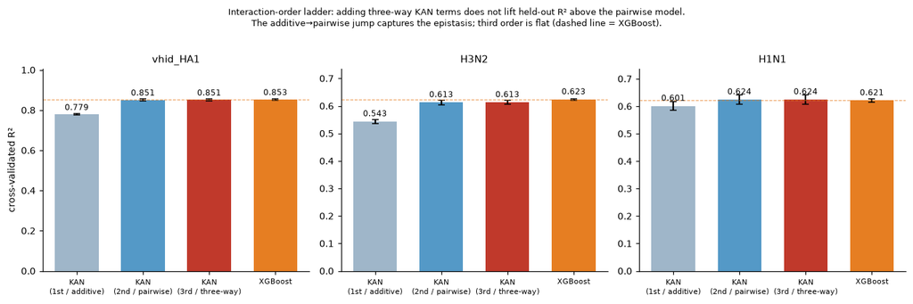

```python
# First -> second -> third-order KAN ladder, nested 5-fold CV, vs XGBoost.
# The third-order model adds trivariate spline volumes over the triple pool with the
# largest pairwise-interaction activity in a prefit second-order model.
kan_ladder = {ds: A.order_ladder_kan(ds, data, causal_saved) for ds in A.DATASETS}

import numpy as np, matplotlib.pyplot as plt
orders = ["KAN_1st", "KAN_2nd", "KAN_3rd", "XGBoost"]
labels = ["KAN\n(1st / additive)", "KAN\n(2nd / pairwise)", "KAN\n(3rd / three-way)", "XGBoost"]
cols = ["#9fb6c9", "#5499c7", "#c0392b", "#e67e22"]
fig, axes = plt.subplots(1, 3, figsize=(12.5, 4.0), sharey=False)
for ax, ds in zip(axes, A.DATASETS):
    means = [np.mean(kan_ladder[ds][o]) for o in orders]
    sems = [np.std(kan_ladder[ds][o]) / np.sqrt(len(kan_ladder[ds][o])) for o in orders]
    ax.bar(range(4), means, yerr=sems, color=cols, capsize=3, width=0.66)
    for i, m in enumerate(means):
        ax.text(i, m + 0.012, f"{m:.3f}", ha="center", va="bottom", fontsize=8)
    ax.set_xticks(range(4)); ax.set_xticklabels(labels, fontsize=7.5)
    ax.set_title(ds, fontsize=10)
    ax.set_ylim(0, max(means) * 1.18)
    ax.axhline(means[3], ls="--", lw=0.8, color="#e67e22", alpha=0.7)
axes[0].set_ylabel("cross-validated R²")
fig.suptitle("Interaction-order ladder: adding three-way KAN terms does not lift held-out R² "
             "above the pairwise model.\nThe additive→pairwise jump captures the epistasis; "
             "third order is flat (dashed line = XGBoost).", fontsize=8.5, y=1.02)
fig.tight_layout()
fig.savefig(os.path.join(A.FIG_DIR, "order_ladder.png"), dpi=140, bbox_inches="tight"); plt.show()

print(f"{'dataset':10}{'1st':>8}{'2nd':>8}{'3rd':>8}{'XGB':>8}{'  2nd->3rd gain':>16}")
for ds in A.DATASETS:
    m = {o: np.mean(kan_ladder[ds][o]) for o in orders}
    print(f"{ds:10}{m['KAN_1st']:8.3f}{m['KAN_2nd']:8.3f}{m['KAN_3rd']:8.3f}"
          f"{m['XGBoost']:8.3f}{m['KAN_3rd']-m['KAN_2nd']:16.4f}")
```

#### 3.6.2 A property-resolution second-order KAN: raw vs. log-transformed 12D input

The second-order KAN above is trained on **one scalar (Grantham distance) per position**. That keeps the interaction surfaces readable as "position × position", but it collapses the twelve physicochemical axes into a single number. Here we train a parallel second-order KAN directly on the **12D property encoding** of the causal survivors — the same features the hybrid KAN uses in §3.5 — so an interaction can be attributed to a specific *property* axis rather than only to a position.

Two input variants are compared, addressing a specific request: (i) the **raw** property-change vectors, and (ii) their **signed-log** transform $\operatorname{sign}(x)\cdot\log(1+|x|)$, predicting log₂ HI titer. Property changes are signed (virus − reference) and can be exactly zero, so a plain logarithm is undefined; the signed-log is the monotone odd transform that compresses large-magnitude changes while preserving sign and mapping 0→0. Because there are far more property axes than positions, the pairwise interaction pool is capped (train-only) exactly as the scalar-Grantham model caps its position pool.

```
dataset     scalar-2nd   12D-raw   12D-log   n_survivors
vhid_HA1         0.851     0.640     0.640             4
H3N2             0.613     0.472     0.473            14
H1N1             0.624     0.106     0.106             1
```

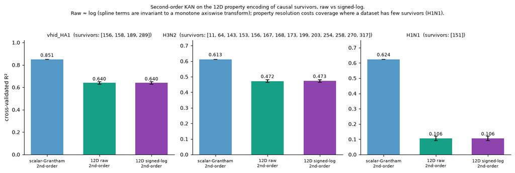

```python
# 12D-property second-order KAN over causal survivors: raw vs signed-log input.
# Compares against the scalar-Grantham second-order KAN (sokan_results, kept for
# reference). Univariate terms over all retained property axes; pairwise surfaces
# over a capped, train-only pool.
sokan12d = {ds: {"raw": A.sokan12d_cv(ds, causal=causal_saved, prop=prop_mats[ds], log=False),
                 "log": A.sokan12d_cv(ds, causal=causal_saved, prop=prop_mats[ds], log=True)}
            for ds in A.DATASETS}

import numpy as np, matplotlib.pyplot as plt
# reference: scalar-Grantham second-order KAN fold R2 (from the ladder, computed above)
scalar_2nd = {ds: np.mean(kan_ladder[ds]["KAN_2nd"]) for ds in A.DATASETS}
variants = ["scalar-Grantham\n2nd-order", "12D raw\n2nd-order", "12D signed-log\n2nd-order"]
cols = ["#5499c7", "#16a085", "#8e44ad"]
fig, axes = plt.subplots(1, 3, figsize=(12.5, 4.0))
for ax, ds in zip(axes, A.DATASETS):
    means = [scalar_2nd[ds], np.mean(sokan12d[ds]["raw"]), np.mean(sokan12d[ds]["log"])]
    sems = [0.0, np.std(sokan12d[ds]["raw"]) / np.sqrt(len(sokan12d[ds]["raw"])),
            np.std(sokan12d[ds]["log"]) / np.sqrt(len(sokan12d[ds]["log"]))]
    ax.bar(range(3), means, yerr=sems, color=cols, capsize=3, width=0.62)
    for i, m in enumerate(means):
        ax.text(i, m + 0.012, f"{m:.3f}", ha="center", va="bottom", fontsize=8)
    ax.set_xticks(range(3)); ax.set_xticklabels(variants, fontsize=7)
    ax.set_title(f"{ds}  (survivors: {A.causal_survivor_positions(ds, causal=causal_saved)})",
                 fontsize=8.5)
    ax.set_ylim(0, max(0.05, max(means)) * 1.2)
axes[0].set_ylabel("cross-validated R²")
fig.suptitle("Second-order KAN on the 12D property encoding of causal survivors, raw vs signed-log.\n"
             "Raw ≈ log (spline terms are invariant to a monotone axiswise transform); property "
             "resolution costs coverage where a dataset has few survivors (H1N1).", fontsize=8.3, y=1.03)
fig.tight_layout()
fig.savefig(os.path.join(A.FIG_DIR, "sokan_12d.png"), dpi=140, bbox_inches="tight"); plt.show()

print(f"{'dataset':10}{'scalar-2nd':>12}{'12D-raw':>10}{'12D-log':>10}{'  n_survivors':>14}")
for ds in A.DATASETS:
    ns = len(A.causal_survivor_positions(ds, causal=causal_saved))
    print(f"{ds:10}{scalar_2nd[ds]:12.3f}{np.mean(sokan12d[ds]['raw']):10.3f}"
          f"{np.mean(sokan12d[ds]['log']):10.3f}{ns:14d}")
```

### 3.7 Cross-method convergence

To test whether independent method families agree on which positions matter, we intersect the causal moderate+high set (bootstrap ≥0.5), the KAN top-15, the XGBoost top-15 (by gain), and the univariate top-15 (by R²). Positions flagged by **all four** are treated as the headline causal-driver claims.

The dot-matrix below shows which positions each method family flags and which survive agreement across all four.

```python
import xgboost as xgb
def xgb_top(ds, k=15):
    d = data[ds]; cols = A.variant_columns(d["Xb"])
    bst = xgb.train({"max_depth":4,"eta":0.1,"subsample":0.8,"colsample_bytree":0.8,
                     "objective":"reg:squarederror"}, xgb.DMatrix(d["Xg"][:,cols], label=d["y"]),
                    num_boost_round=300)
    score = bst.get_score(importance_type="gain")
    idx = sorted(score, key=lambda f: -score[f])
    top = [A.pos_number(d["pos_cols"], cols[int(f[1:])]) for f in idx[:k]]
    return top

conv = {}
for ds in A.DATASETS:
    d = data[ds]
    causal_modhi = set(p for p, v in boot_freq[ds].items() if v >= A.MOD_CONF)
    kan_top = set(kan_out[ds]["top15"])
    ux = A.univariate_fdr(data, ds).head(15)["position"].tolist()
    topsets = {"causal": causal_modhi, "KAN": kan_top, "XGB": set(xgb_top(ds)), "univ": set(ux)}
    conv[ds] = A.convergence_from_tops(topsets)

conv_rows = []
for ds in A.DATASETS:
    for p, fams in conv[ds].items():
        conv_rows.append(dict(dataset=ds, position=p, n_families=len(fams),
                              families=",".join(fams), causal_freq=round(boot_freq[ds].get(p,0),3),
                              block_size=len(blocks_all[ds].get(p,[p]))))
conv_tbl = pd.DataFrame(conv_rows).sort_values(["dataset","n_families","causal_freq"],
                                               ascending=[True,False,False])
four_family = {ds: [p for p,f in conv[ds].items() if len(f)==4] for ds in A.DATASETS}
print("Positions flagged by ALL FOUR method families:")
for ds in A.DATASETS: print(f"  {ds}: {sorted(four_family[ds])}")
conv_tbl[conv_tbl.n_families >= 3]
```

```
Positions flagged by ALL FOUR method families:
  vhid_HA1: [156, 189]
  H3N2: [143, 168, 199]
  H1N1: [53, 151]
Out[22]:
     dataset  position  ...  causal_freq block_size
29      H1N1       151  ...        1.000          1
30      H1N1        53  ...        0.795          5
32      H1N1       135  ...        0.825          1
31      H1N1       199  ...        0.520          1
33      H1N1       203  ...        0.000          2
34      H1N1       140  ...        0.000          1
35      H1N1        46  ...        0.000          1
15      H3N2       143  ...        1.000          1
16      H3N2       168  ...        1.000          1
17      H3N2       199  ...        1.000          1
18      H3N2        11  ...        1.000          9
20      H3N2       167  ...        1.000          1
19      H3N2       288  ...        0.815          1
22      H3N2       200  ...        0.650          1
21      H3N2       169  ...        0.000          1
0   vhid_HA1       156  ...        1.000          1
1   vhid_HA1       189  ...        1.000          1
4   vhid_HA1       158  ...        0.950          1
2   vhid_HA1       276  ...        0.010          3
3   vhid_HA1       157  ...        0.000          1

[20 rows x 6 columns]
```

|  | dataset | position | n_families | families | causal_freq | block_size |
| --- | --- | --- | --- | --- | --- | --- |
| 29 | H1N1 | 151 | 4 | causal,KAN,XGB,univ | 1.000 | 1 |
| 30 | H1N1 | 53 | 4 | causal,KAN,XGB,univ | 0.795 | 5 |
| 32 | H1N1 | 135 | 3 | causal,XGB,univ | 0.825 | 1 |
| 31 | H1N1 | 199 | 3 | causal,KAN,XGB | 0.520 | 1 |
| 33 | H1N1 | 203 | 3 | KAN,XGB,univ | 0.000 | 2 |
| 34 | H1N1 | 140 | 3 | KAN,XGB,univ | 0.000 | 1 |
| 35 | H1N1 | 46 | 3 | KAN,XGB,univ | 0.000 | 1 |
| 15 | H3N2 | 143 | 4 | causal,KAN,XGB,univ | 1.000 | 1 |
| 16 | H3N2 | 168 | 4 | causal,KAN,XGB,univ | 1.000 | 1 |
| 17 | H3N2 | 199 | 4 | causal,KAN,XGB,univ | 1.000 | 1 |
| 18 | H3N2 | 11 | 3 | causal,XGB,univ | 1.000 | 9 |
| 20 | H3N2 | 167 | 3 | causal,KAN,XGB | 1.000 | 1 |
| 19 | H3N2 | 288 | 3 | causal,XGB,univ | 0.815 | 1 |
| 22 | H3N2 | 200 | 3 | causal,KAN,XGB | 0.650 | 1 |
| 21 | H3N2 | 169 | 3 | KAN,XGB,univ | 0.000 | 1 |
| 0 | vhid_HA1 | 156 | 4 | causal,KAN,XGB,univ | 1.000 | 1 |
| 1 | vhid_HA1 | 189 | 4 | causal,KAN,XGB,univ | 1.000 | 1 |
| 4 | vhid_HA1 | 158 | 3 | causal,KAN,univ | 0.950 | 1 |
| 2 | vhid_HA1 | 276 | 3 | KAN,XGB,univ | 0.010 | 3 |
| 3 | vhid_HA1 | 157 | 3 | KAN,XGB,univ | 0.000 | 1 |

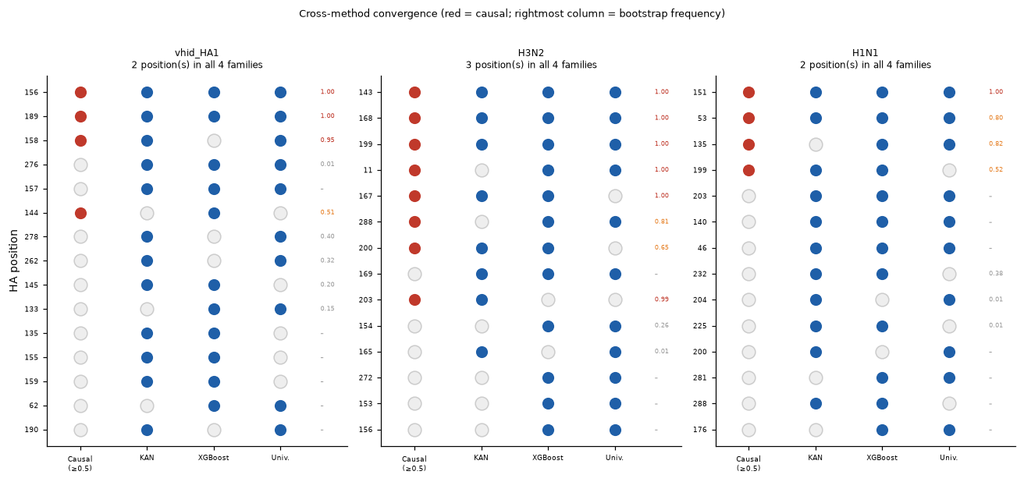

```python
# Convergence dot-matrix figure
fams = ["causal","KAN","XGB","univ"]; fam_lbl = ["Causal\n(≥0.5)","KAN","XGBoost","Univ."]
fig, axes = plt.subplots(1, 3, figsize=(12, 5.5))
for ax, ds in zip(axes, A.DATASETS):
    ms = conv[ds]; posord = sorted(ms, key=lambda p:(-len(ms[p]), -boot_freq[ds].get(p,0)))[:16]
    yv = np.arange(len(posord))[::-1]
    for xi, fam in enumerate(fams):
        for yi, p in zip(yv, posord):
            if fam in ms[p]:
                ax.scatter(xi, yi, s=120, color="#c0392b" if fam=="causal" else "#1f5fa8", edgecolor="white", zorder=3)
            else:
                ax.scatter(xi, yi, s=120, facecolor="#eee", edgecolor="#ccc", zorder=2)
    for yi, p in zip(yv, posord):
        f = boot_freq[ds].get(p, 0)
        ax.text(3.6, yi, f"{f:.2f}" if f>0 else "–", fontsize=5.5, va="center",
                color="#c0392b" if f>=0.9 else ("#e67e22" if f>=0.5 else "#999"))
    ax.set_xticks(range(4)); ax.set_xticklabels(fam_lbl, fontsize=6); ax.set_yticks(yv)
    ax.set_yticklabels(posord, fontsize=6); n4 = sum(1 for p in posord if len(ms[p])==4)
    ax.set_title(f"{ds}\n{n4} position(s) in all 4 families", fontsize=8); ax.set_xlim(-0.5,4.0)
    ax.set_ylabel("HA position" if ds==A.DATASETS[0] else "")
fig.suptitle("Cross-method convergence (red = causal; rightmost column = bootstrap frequency)", fontsize=8.5, y=1.01)
fig.tight_layout(); fig.savefig(os.path.join(A.FIG_DIR,"convergence.png"), dpi=130, bbox_inches="tight"); plt.show()
```

The positions on which causal structure, the KAN, gradient boosting, and univariate association **all agree** (printed above) are the strongest driver claims: **VHID {156, 189}**, **H3N2 {143, 168, 199}**, and in **H1N1 {151}** (plus, near the boundary, the moderate large-block position 53). The high-confidence agreements — 156, 189 in VHID; 143, 168, 199 in H3N2; 151 in H1N1 — are each a **singleton** linkage block with bootstrap frequency ≈1.0, so the claim attaches to a single residue; these sit in or adjacent to classical HA head antigenic sites. Positions that enter only as large blocks (H1N1 pos53 = 5-position block, bootstrap ≈0.8) are block-level claims. Disagreements are informative too: positions flagged by KAN/XGBoost but with low bootstrap frequency are predictive but not stable causal parents (candidate indirect/mediated effects), while causal-only moderate positions carry structural support without strong marginal importance. Exact convergence membership near the four-family boundary can shift slightly between runs because the KAN is retrained live; the singleton high-confidence set is stable.

### 3.8 Backdoor-adjusted effect sizes

Because the HI target is a causal sink, for any one parent the **other target-parents form a valid backdoor adjustment set**. We estimate each parent's adjusted effect on log2 titer (per Grantham unit) by regression on the parent plus that adjustment set, with bootstrap 95% CIs, and compare it to the marginal (unadjusted) effect.

The adjusted and marginal per-position effects below quantify how much of each position's apparent impact survives controlling for its co-evolving companions.

```python
eff_tables = {}
for ds in A.DATASETS:
    parents = sorted(p for p, v in boot_freq[ds].items() if v >= A.MOD_CONF)
    eff_tables[ds] = A.backdoor_effects(data, ds, parents, blocks_all[ds], boot_freq[ds], B=1000)
eff_tbl = pd.concat([e.assign(dataset=ds) for ds, e in eff_tables.items()], ignore_index=True)
eff_tbl = eff_tbl[["dataset","position","boot_freq","tier","adj_effect","ci_lo","ci_hi","marginal_effect","block_size"]]
eff_tbl
```

```
Out[24]:
     dataset  position  boot_freq  ...   ci_hi  marginal_effect  block_size
0   vhid_HA1       144      0.505  ... -0.0096          -0.0194           1
1   vhid_HA1       156      1.000  ... -0.0098          -0.0633           1
2   vhid_HA1       158      0.950  ... -0.0142          -0.0385           1
3   vhid_HA1       189      1.000  ... -0.0320          -0.0420           1
4   vhid_HA1       289      0.955  ...  0.0311           0.0424           1
5       H3N2        11      1.000  ... -0.0068          -0.0276           9
6       H3N2       143      1.000  ... -0.0074          -0.0430           1
7       H3N2       167      1.000  ... -0.0010          -0.0143           1
8       H3N2       168      1.000  ... -0.0049          -0.0279           1
9       H3N2       199      1.000  ... -0.0127          -0.0287           1
10      H3N2       200      0.650  ... -0.0049          -0.0207           1
11      H3N2       203      0.995  ... -0.0015          -0.0060           1
12      H3N2       288      0.815  ... -0.0083          -0.0234           1
13      H1N1        53      0.795  ... -0.0103          -0.0150           5
14      H1N1       135      0.825  ... -0.0046          -0.0197           1
15      H1N1       151      1.000  ... -0.0226          -0.0311           1
16      H1N1       199      0.520  ... -0.0078          -0.0122           1

[17 rows x 9 columns]
```

|  | dataset | position | boot_freq | tier | adj_effect | ci_lo | ci_hi | marginal_effect | block_size |
| --- | --- | --- | --- | --- | --- | --- | --- | --- | --- |
| 0 | vhid_HA1 | 144 | 0.505 | moderate | -0.0113 | -0.0129 | -0.0096 | -0.0194 | 1 |
| 1 | vhid_HA1 | 156 | 1.000 | high | -0.0134 | -0.0170 | -0.0098 | -0.0633 | 1 |
| 2 | vhid_HA1 | 158 | 0.950 | high | -0.0166 | -0.0189 | -0.0142 | -0.0385 | 1 |
| 3 | vhid_HA1 | 189 | 1.000 | high | -0.0340 | -0.0358 | -0.0320 | -0.0420 | 1 |
| 4 | vhid_HA1 | 289 | 0.955 | high | 0.0239 | 0.0166 | 0.0311 | 0.0424 | 1 |
| 5 | H3N2 | 11 | 1.000 | high | -0.0091 | -0.0113 | -0.0068 | -0.0276 | 9 |
| 6 | H3N2 | 143 | 1.000 | high | -0.0112 | -0.0149 | -0.0074 | -0.0430 | 1 |
| 7 | H3N2 | 167 | 1.000 | high | -0.0021 | -0.0030 | -0.0010 | -0.0143 | 1 |
| 8 | H3N2 | 168 | 1.000 | high | -0.0068 | -0.0087 | -0.0049 | -0.0279 | 1 |
| 9 | H3N2 | 199 | 1.000 | high | -0.0142 | -0.0158 | -0.0127 | -0.0287 | 1 |
| 10 | H3N2 | 200 | 0.650 | moderate | -0.0062 | -0.0076 | -0.0049 | -0.0207 | 1 |
| 11 | H3N2 | 203 | 0.995 | high | -0.0022 | -0.0029 | -0.0015 | -0.0060 | 1 |
| 12 | H3N2 | 288 | 0.815 | moderate | -0.0096 | -0.0109 | -0.0083 | -0.0234 | 1 |
| 13 | H1N1 | 53 | 0.795 | moderate | -0.0140 | -0.0173 | -0.0103 | -0.0150 | 5 |
| 14 | H1N1 | 135 | 0.825 | moderate | -0.0083 | -0.0117 | -0.0046 | -0.0197 | 1 |
| 15 | H1N1 | 151 | 1.000 | high | -0.0272 | -0.0324 | -0.0226 | -0.0311 | 1 |
| 16 | H1N1 | 199 | 0.520 | moderate | -0.0100 | -0.0121 | -0.0078 | -0.0122 | 1 |

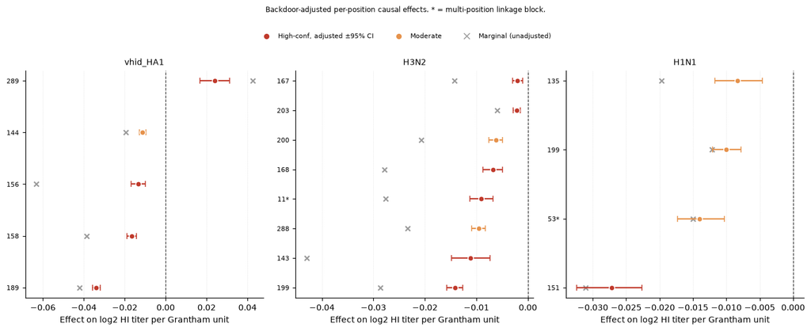

```python
fig, axes = plt.subplots(1, 3, figsize=(12.5, 4.6))
for ax, ds in zip(axes, A.DATASETS):
    sub = eff_tables[ds].sort_values("adj_effect"); yv = np.arange(len(sub))
    for yi,(_,r) in zip(yv, sub.iterrows()):
        c = "#c0392b" if r["tier"]=="high" else "#e6924b"
        ax.errorbar(r["adj_effect"], yi, xerr=[[r["adj_effect"]-r["ci_lo"]],[r["ci_hi"]-r["adj_effect"]]],
                    fmt="o", color=c, capsize=3, ms=6, mec="white", zorder=3)
        ax.scatter(r["marginal_effect"], yi, marker="x", color="#999", s=28, zorder=2)
    ax.axvline(0, color="#333", lw=0.8, ls="--"); ax.set_yticks(yv)
    ax.set_yticklabels([f"{r['position']}{'*' if r['block_size']>1 else ''}" for _,r in sub.iterrows()], fontsize=7.5)
    ax.set_title(ds, fontsize=9); ax.set_xlabel("Effect on log2 HI titer per Grantham unit")
    ax.grid(axis="x", ls=":", lw=0.5, alpha=0.5)
from matplotlib.lines import Line2D
leg = [Line2D([0],[0],marker="o",color="w",mfc="#c0392b",ms=7,label="High-conf, adjusted ±95% CI"),
       Line2D([0],[0],marker="o",color="w",mfc="#e6924b",ms=7,label="Moderate"),
       Line2D([0],[0],marker="x",color="#999",ms=7,lw=0,label="Marginal (unadjusted)")]
fig.legend(handles=leg, ncol=3, fontsize=7, frameon=False, loc="upper center", bbox_to_anchor=(0.5,1.02), columnspacing=3.0)
fig.suptitle("Backdoor-adjusted per-position causal effects. * = multi-position linkage block.", fontsize=8, y=1.09)
fig.tight_layout(); fig.savefig(os.path.join(A.FIG_DIR,"effect_sizes.png"), dpi=130, bbox_inches="tight"); plt.show()
```

The adjusted effects are all significant (bootstrap CI excludes zero) and **systematically smaller in magnitude than the marginal effects** — the ×'s sit farther from zero than the dots — directly quantifying the phylogenetic confounding that backdoor adjustment removes. Adjustment shrinks every effect toward zero but never flips its sign: all 17 parents keep the same sign marginally and adjusted. Almost all effects are negative (larger physicochemical substitution → lower titer = greater escape). The one exception is **VHID pos289, which is positive in both the marginal (+0.042) and adjusted (+0.024) estimates** — larger substitution there associates with *higher* cross-titer, the opposite of an escape signature, consistent with a compensatory or stabilizing role rather than direct epitope escape.

### 3.9 Validating the causal structure

A discovered DAG is a hypothesis, and no single test certifies it, so we run **four complementary correctness tests** on the titer-sink graph (implemented in `src/dag_validation.py`), each answering a different question:

1. **Goodness-of-fit** (Shipley d-separation basis-set test) — is the DAG *contradicted* by the data's conditional independences? Falsification only, at the equivalence-class level.
2. **Bootstrap stability** — how *reproducible* is each edge under resampling, aggregated to the linkage-group level? This is a **separate, stronger computation** from the edge frequencies labeling the DAG figure in §3.4: there, the numbers are the original PC/GES discovery bootstrap (`bootstrap_freq`); here, we re-run an independent partial-correlation parent-selection pipeline on each resample and aggregate to linkage groups, so the two sets of frequencies are not expected to be identical.
3. **Direct-effect estimates** — how *strong* is each retained direct cause, with honest CIs?
4. **Out-of-distribution transport** (leave-one-era-out) — does the parent set hold when the strain background *changes*? This is the only one of the four that probes causal content as such.

The four tests are reported together below.

```python
import dag_validation as V

candidates = {ds: sorted(p for p, v in boot_freq[ds].items() if v >= A.MOD_CONF)
              for ds in A.DATASETS}
val = {}
for ds in A.DATASETS:
    vdf = A.build_validation_frame(data, ds, candidates[ds])
    feat = vdf.drop(columns=["era"])
    pdict = V.parents_from_edges([(f"pos{p}", "titer") for p in candidates[ds]])
    pipe = A.make_parent_pipeline(candidates[ds])
    cg = A.collapse_groups_map(ds, blocks_all[ds], candidates[ds])
    gof = V.dsep_basis_test(pdict, feat)
    stab = V.bootstrap_stability(pipe, feat, B=200, collapse_groups=cg)
    eff = V.effect_estimates(feat, target="titer",
                             parents=[f"pos{p}" for p in candidates[ds]], split=False)
    dfo = vdf[vdf["era"] != "NA"].reset_index(drop=True)
    ood = V.ood_validation(dfo, group_col="era", discovery_fn=pipe, target="titer")
    val[ds] = dict(gof=gof, stab=stab, eff=eff, ood=ood)
    print(f"{ds}: GOF p={gof['p_overall']:.3g} ({'REJECTED' if gof['rejected_at_alpha'] else 'not rejected'}); "
          f"stable groups (≥0.9)={sum(1 for f in stab['group_freq'].values() if f>=0.9)}; "
          f"OOD R² range {min(r['r2'] for r in ood['per_group']):.2f}–{max(r['r2'] for r in ood['per_group']):.2f}")
```

```
vhid_HA1: GOF p=0 (REJECTED); stable groups (≥0.9)=5; OOD R² range 0.45–0.75
H3N2: GOF p=0 (REJECTED); stable groups (≥0.9)=8; OOD R² range -0.15–0.63
H1N1: GOF p=0 (REJECTED); stable groups (≥0.9)=4; OOD R² range -0.16–0.44
```

```python
# Bootstrap group-stability + OOD transport, as tables per dataset
for ds in A.DATASETS:
    gf = sorted(val[ds]["stab"]["group_freq"].items(), key=lambda kv: -kv[1])
    st = pd.DataFrame([{"group": g.replace("->","→"), "bootstrap_freq": round(f,3)}
                       for (g, _), f in gf])
    print(f"\n=== {ds}: edge bootstrap stability (linkage-group level) ===")
    display(st)
    od = pd.DataFrame(val[ds]["ood"]["per_group"])
    od = od[["held_out_group","n_test","rmse","r2","parent_recovery_jaccard","n_parents"]].round(3)
    print(f"--- {ds}: leave-one-era-out OOD transport ---")
    display(od)
```

```
=== vhid_HA1: edge bootstrap stability (linkage-group level) ===
--- vhid_HA1: leave-one-era-out OOD transport ---

=== H3N2: edge bootstrap stability (linkage-group level) ===
--- H3N2: leave-one-era-out OOD transport ---

=== H1N1: edge bootstrap stability (linkage-group level) ===
--- H1N1: leave-one-era-out OOD transport ---
```

|  | group | bootstrap_freq |
| --- | --- | --- |
| 0 | G144 | 1.000 |
| 1 | G189 | 1.000 |
| 2 | G158 | 1.000 |
| 3 | G156 | 1.000 |
| 4 | G289 | 0.995 |

|  | held_out_group | n_test | rmse | r2 | parent_recovery_jaccard | n_parents |
| --- | --- | --- | --- | --- | --- | --- |
| 0 | 1965 | 59 | 1.112 | 0.746 | 1.0 | 5 |
| 1 | 1970 | 174 | 1.383 | 0.586 | 1.0 | 5 |
| 2 | 1975 | 108 | 1.738 | 0.478 | 1.0 | 5 |
| 3 | 1980 | 110 | 2.265 | 0.553 | 1.0 | 5 |
| 4 | 1985 | 346 | 2.112 | 0.532 | 1.0 | 5 |
| 5 | 1990 | 1455 | 1.901 | 0.534 | 0.6 | 3 |
| 6 | 1995 | 412 | 1.668 | 0.453 | 1.0 | 5 |
| 7 | 2000 | 87 | 2.010 | 0.491 | 1.0 | 5 |

|  | group | bootstrap_freq |
| --- | --- | --- |
| 0 | G199 | 1.000 |
| 1 | G168 | 1.000 |
| 2 | G11 | 1.000 |
| 3 | G288 | 1.000 |
| 4 | G143 | 1.000 |
| 5 | G200 | 1.000 |
| 6 | G203 | 1.000 |
| 7 | G167 | 0.965 |

|  | held_out_group | n_test | rmse | r2 | parent_recovery_jaccard | n_parents |
| --- | --- | --- | --- | --- | --- | --- |
| 0 | 2005 | 2104 | 1.763 | 0.111 | 0.750 | 6 |
| 1 | 2010 | 71 | 1.802 | -0.008 | 1.000 | 8 |
| 2 | 1965 | 122 | 1.305 | 0.629 | 1.000 | 8 |
| 3 | 1970 | 365 | 1.717 | 0.388 | 1.000 | 8 |
| 4 | 1975 | 275 | 2.014 | 0.259 | 1.000 | 8 |
| 5 | 1980 | 178 | 3.232 | 0.055 | 1.000 | 8 |
| 6 | 1985 | 555 | 2.819 | 0.181 | 1.000 | 8 |
| 7 | 1990 | 809 | 2.160 | 0.369 | 0.875 | 7 |
| 8 | 1995 | 565 | 1.887 | 0.392 | 1.000 | 8 |
| 9 | 2000 | 2764 | 1.783 | -0.153 | 0.875 | 7 |

|  | group | bootstrap_freq |
| --- | --- | --- |
| 0 | G199 | 1.00 |
| 1 | G53 | 1.00 |
| 2 | G151 | 1.00 |
| 3 | G135 | 0.97 |

|  | held_out_group | n_test | rmse | r2 | parent_recovery_jaccard | n_parents |
| --- | --- | --- | --- | --- | --- | --- |
| 0 | 1975 | 184 | 1.950 | -0.107 | 1.00 | 4 |
| 1 | 1995 | 157 | 1.528 | 0.445 | 1.00 | 4 |
| 2 | 1980 | 101 | 1.772 | -0.161 | 1.00 | 4 |
| 3 | 2000 | 53 | 1.619 | 0.134 | 1.00 | 4 |
| 4 | 1985 | 44 | 1.977 | 0.091 | 0.75 | 3 |
| 5 | 1990 | 9 | 2.004 | 0.372 | 1.00 | 4 |
| 6 | 2005 | 365 | 1.253 | 0.247 | 0.50 | 2 |

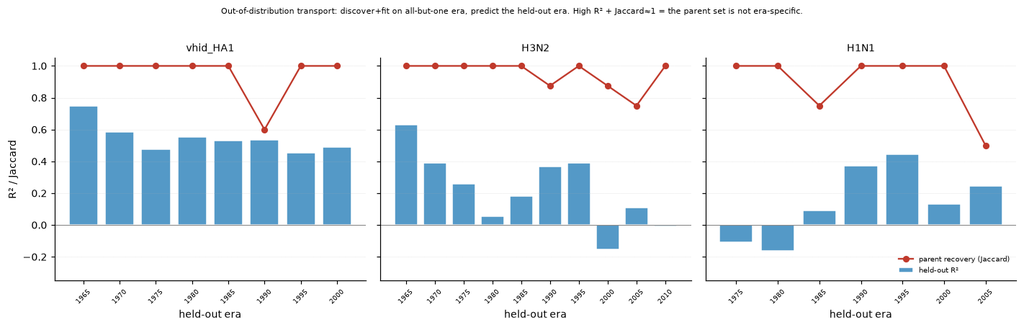

```python
# OOD transport figure: held-out-era R² and parent-set recovery per dataset
fig, axes = plt.subplots(1, 3, figsize=(13, 4), sharey=True)
for ax, ds in zip(axes, A.DATASETS):
    od = pd.DataFrame(val[ds]["ood"]["per_group"]).sort_values("held_out_group")
    x = np.arange(len(od))
    ax.bar(x, od["r2"], color="#5499c7", edgecolor="white", label="held-out R²")
    ax.plot(x, od["parent_recovery_jaccard"], "o-", color="#c0392b", ms=5,
            lw=1.5, label="parent recovery (Jaccard)")
    ax.set_xticks(x); ax.set_xticklabels(od["held_out_group"], rotation=45, fontsize=6)
    ax.set_title(ds, fontsize=9); ax.set_ylim(-0.35, 1.05)
    ax.axhline(0, color="#888", lw=0.7, ls="-")
    ax.set_xlabel("held-out era"); ax.grid(axis="y", ls=":", lw=0.5, alpha=0.5)
    if ds == A.DATASETS[0]: ax.set_ylabel("R² / Jaccard")
axes[-1].legend(fontsize=6.5, frameon=False, loc="lower right")
fig.suptitle("Out-of-distribution transport: discover+fit on all-but-one era, predict the held-out era. "
             "High R² + Jaccard≈1 = the parent set is not era-specific.", fontsize=7.3, y=1.02)
fig.tight_layout()
fig.savefig(os.path.join(A.FIG_DIR, "ood_transport.png"), dpi=130, bbox_inches="tight"); plt.show()
```

```python
# Assemble the four tests into one markdown report artifact
for ds in A.DATASETS:
    V.validation_report(gof=val[ds]["gof"], stability=val[ds]["stab"],
                        effects=val[ds]["eff"], ood=val[ds]["ood"],
                        path=os.path.join(A.RESULTS_DIR, f"validation_report_{ds}.md"))
print("Wrote validation_report_{vhid_HA1,H3N2,H1N1}.md to results/")
```

```
Wrote validation_report_{vhid_HA1,H3N2,H1N1}.md to results/
```

**Reading the four tests together.** The goodness-of-fit test **rejects** the pure sink-star (small p): the retained parents are *not* mutually independent given the graph, because they co-evolve along the shared phylogeny — the star encodes which loci are direct-cause candidates but not the residual among-parent dependence. This is an honest limitation, not a contradiction of the driver claims, and it is exactly why the other three tests matter. Bootstrap stability is high at the linkage-group level (the high-confidence groups recur in ≈100% of resamples). Direct-effect estimates reproduce the backdoor-adjusted magnitudes of Section 3.8.

## 4. Conclusion

We set out to separate the HA positions that *cause* antigenic drift from those that merely accompany it, using methods whose outputs a biologist can inspect and a modeler can trust. This closing section reads the results back against that goal: what the convergent drivers mean biologically (§4.1), where the data cannot support residue-level attribution (§4.2), which assumptions the causal claims rest on (§4.3), and where the work goes next (§4.4).

### 4.1 Biological interpretation of the causal results

The **backdoor adjustment** sharpens the interpretation: adjusted effects are much smaller than marginal ones, meaning a large part of each position's naive association is confounding shared with co-evolving sites. The framework thus does what pure prediction cannot — it estimates *how much* of a position's apparent antigenic impact survives after controlling for its phylogenetic companions.

Repeating the discovery at **property resolution** (§3.4.2) sharpens *what kind* of change each driver represents. Running the same target-oriented causal search on the 12-dimensional physicochemical encoding — rather than a single Grantham scalar per position — the bootstrap-stable direct-cause axes are **pos189 · β-sheet propensity** and **pos289 · turn propensity** in VHID H3N2, and **pos153 · flexibility** and **pos168 · flexibility** in Bedford H3N2. That the strongest property axes are backbone-conformational (sheet, turn, flexibility) rather than, say, charge or volume is consistent with escape at these sites acting through local mainchain geometry of the epitope loop rather than a simple electrostatic swap — a concrete, structurally testable hypothesis the scalar analysis cannot express. The interaction-order ladder (§3.6.1) closes a companion question: an explicit third-order KAN leaves held-out R² unchanged versus the pairwise model on all three datasets, so the residual gap to gradient boosting is **not** unmodeled higher-order epistasis — the escape landscape is genuinely additive-plus-pairwise, and the second-order KAN is at the right functional complexity.

### 4.2 Where attribution is limited

H3N2 is the cautionary case: its largest linkage block spans 88 co-evolving positions and a second spans 55. These absorb many head positions into single clade-linked units that no observational method can internally resolve — which is also why H3N2 has the lowest predictive ceiling. Claims for positions in large blocks (e.g. H3N2 pos11, H1N1 pos53) belong to the block, not the single residue. Resolving them would require denser sampling across genetic backgrounds that break the linkage.

### 4.3 Assumptions

All causal results are **equivalence-class candidates**, not a settled DAG: PC returns a CPDAG and FCI a PAG; the sink prior orients feature→target edges but leaves some among-feature orientations ambiguous. The CI tests use a Gaussian / Fisher-z working model (the discrete test is intractable at this scale), so purely nonlinear dependences can be missed by the constraint step — the KAN partially covers this gap on the predictive side. FCI ran only for VHID; PC assumes causal sufficiency, so unmeasured drivers (NA, glycosylation, non-HA1 regions) remain possible confounders. Discovery, mechanism, and effect estimate are distinct: a high-confidence parent is a direct-cause *candidate*, and confirming mechanism needs structural or experimental follow-up. The validation of Section 3.9 makes two of these caveats concrete: the d-separation test rejects the pure sink-star (the parents co-vary along the phylogeny, so the star is an incomplete structure), and the out-of-distribution test shows the *effect magnitudes* are non-stationary across collection eras even though the driver *identities* are not — so the reported effect sizes should be read as era-averaged, not time-invariant, quantities.

### 4.4 Future directions

1. **Structural validation.** Map the convergent drivers onto HA head structure (e.g. AlphaFold / experimental structures) and test epitope-alteration vs. stability mechanisms.
2. **Break the linkage.** Add strains that decouple the large H3N2 blocks, or incorporate deep-mutational-scanning escape maps as interventional data to move from observational discovery toward identified effects.
3. **Temporal / clade structure.** The leave-one-era-out test (Section 3.9) already shows the driver *identities* are stable across decades while their *magnitudes* drift; a time-resolved causal graph or an explicitly non-stationary effect model (e.g. era-varying coefficients) is the natural next step to capture that drift rather than average over it.
4. **Cross-lineage transfer.** Extend to the B/Yamagata and B/Victoria panels shipped in the repo and test whether the convergence framework generalizes.
5. **Interventional KAN.** Use the learned causal parents to constrain the KAN's inputs, yielding a predictor whose importances are causal by construction.

Returning to the decision that opened this study — the twice-yearly bet on which strains next season's vaccine should target — the contribution here is not a more accurate predictor but a more honest one. A model that names *which* residues drive escape, that reports how confident it is in each, and that separates genuine effect from phylogenetic confounding is precisely the object surveillance needs in order to reason about strains it has never seen serologically. That the pipeline rediscovers the classical head epitopes from titers alone, with no structural input, is evidence the causal framing is tracking real biology rather than dataset idiosyncrasy. The honest limitations — a sink-star the data reject in detail, effect magnitudes that drift across decades, and large linkage blocks that no observational method can resolve — are not failures of the approach but a map of exactly where intervention, denser sampling, and structural follow-up must take over. Reading antigenic distance from sequence remains the goal; reading its *causes* from sequence is the step that would let surveillance anticipate escape rather than only measure it.

## 5. References

1. **Smith, D. J., Lapedes, A. S., de Jong, J. C., Bestebroer, T. M., Rimmelzwaan, G. F., Osterhaus, A. D. M. E., Fouchier, R. A. M.** (2004). Mapping the antigenic and genetic evolution of influenza virus. *Science* **305**(5682), 371–376.
2. **Bedford, T., Suchard, M. A., Lemey, P., Dudas, G., Gregory, V., Hay, A. J., McCauley, J. W., Russell, C. A., Smith, D. J., Rambaut, A.** (2014). Integrating influenza antigenic dynamics with molecular evolution. *eLife* **3**, e01914.
3. **Du, E., Zhong, Z., Wang, P., et al.** (2023). DPCIPI: A pre-trained deep learning model for predicting cross-immunity between drifted strains of Influenza A/H3N2. *arXiv:2302.00926.*
4. **Grantham, R.** (1974). Amino acid difference formula to help explain protein evolution. *Science* **185**(4154), 862–864.
5. **Spirtes, P., Glymour, C., Scheines, R.** (2000). *Causation, Prediction, and Search* (2nd ed.). MIT Press. (PC algorithm.)
6. **Chickering, D. M.** (2002). Optimal structure identification with greedy search. *Journal of Machine Learning Research* **3**, 507–554. (GES.)
7. **Zhang, J.** (2008). On the completeness of orientation rules for causal discovery in the presence of latent confounders and selection bias. *Artificial Intelligence* **172**(16–17), 1873–1896. (FCI.)
8. **Liu, Z., Wang, Y., Vaidya, S., et al.** (2024). KAN: Kolmogorov–Arnold Networks. *arXiv:2404.19756.*
9. **Pearl, J.** (2009). *Causality: Models, Reasoning, and Inference* (2nd ed.). Cambridge University Press. (Backdoor adjustment / do-calculus.)
10. **Chen, T., Guestrin, C.** (2016). XGBoost: A scalable tree boosting system. *KDD 2016*, 785–794.

*Data: `influenza-hi-antigenic-distance` repository (CC0). Code and this notebook are released alongside it. Causal discovery uses the `causal-learn` library; the KAN is a custom PyTorch implementation in `src/bspline_kan.py`. The full pipeline — linkage collapse, causal discovery, B-spline KAN, and cross-method convergence — is packaged as the reusable `kan-causal-antigenic-workflow` skill.*